# SourceMeter 9.2 for Java

# Introduction

FrontEndART SourceMeter for Java is a source code analyzer tool, which can perform deep static analysis of the source code of complex Java systems (https://www.sourcemeter.com).

The source code of a program is usually its only up-to-date documentation. At the same time, the source code is the exquisite bearer of knowledge, business processes and methodology, accumulated over a long period of time. Source code quality decrease, which happens due to many quick fixes and time pressure, results in the increase of development and testing costs, and operational risks. In spite of this, the source code usually receives hostile treatment and is merely considered as a tool.

FrontEndART has developed SourceMeter based on the Columbus technology researched and developed at the [Department of Software Engineering](http://www.sed.inf.u-szeged.hu/softwarequality) of the University of Szeged. SourceMeter provides deep static analysis of source code. Using the results of the analysis, the quality of the analyzed source code can be improved and developed both in the short- and long term in a directed way.

All features of SourceMeter for Java are free, except the VulnerabilityHunter, FaultHunter, and AndroidHunter modules.

## Product characteristics

The most important product characteristics of FrontEndART SourceMeter are the following:

- Platform-independent command line tools
- Powerful filter management
- Interprocedural symbolic execution engine
- Coding issue detection:
  - [OWASP](https://www.owasp.org) vulnerability issues (VulnerabilityHunter module)
  - Runtime exception issues (RuntimeExceptionHunter module)
  - Common programming mistakes (FaultHunter module)
  - Android programming mistakes (AndroidHunter module)
  - Metric threshold violations (MetricHunter module)
  - Re-prioritized and carefully selected [PMD](https://pmd.github.io) 6.12.0 coding rule violations [^1]
  - [SpotBugs](https://spotbugs.github.io) 3.1.11 coding rule violations
  - [SONARQUBE™](https://www.sonarqube.org) platform 8.0 (“SonarQube” in the following) coding rule violations
- Clone detection (copy-pasted source code fragments) extended with clone tracking and “clone smells”
  - Syntax-based, so-called Type-2 clones
- Metrics calculation at component, file, package, class, and method levels:
  - Source code metrics
  - Clone metrics
  - Coding rule violation metrics

By continuous static analysis, the software developers can:

- reduce the software erosion rate and this way decrease development costs;
- coding problems can be identified before testing, so the number of test iterations and the testing costs can be reduced;
- the number of errors in delivered software can be reduced, so the operational risks can be decreased, increasing the company’s reputation.

SourceMeter can analyze source code conforming to Java 10.

With the help of the filtering mechanism it is possible to specify a certain part of the ASG to be used (or not to be used) during the analysis, hence the results can be made more focused and the usage of memory and CPU can be reduced (e.g. generated source files or test code can be filtered out).

Visit our corporate website at http://www.frontendart.com to find the latest information about SourceMeter and read more about related products and services. Note, that if you are using only the free features of SourceMeter, we do not provide any free support for it. However, FrontEndART offers support services, so please feel free to search for solutions to your problems on our website and contact us with any questions you might have. We welcome feedback about the usability and eventual issues of the tool and further development suggestions at .

## Background

During the static analysis, an Abstract Semantic Graph (ASG) is constructed from the language elements of the source code. This ASG is then processed by the different tools in the package to calculate product metrics, identify copy-pasted code (clones), coding rule violations, etc.

# Installation

## Supported platforms

SourceMeter supports the following x64 platforms:

- Microsoft Windows 7, 8, 8.1, and 10
- Microsoft Windows 2008 R2 Server
- Microsoft Windows 2012 Server
- GNU/Linux with kernel version 2.6.18 and GNU C library 2.11 or newer

## Requirements

In order to use SourceMeter it is necessary to have JDK 10 or 11 installed on the computer and the necessary environment variables must be set correctly (JAVA_HOME, PATH).

In case of Windows, the Microsoft Visual C++ 2017 Redistributable Package must be installed. It can be downloaded from the following URL:

- https://aka.ms/vs/15/release/vc_redist.x64.exe (x64)

The Linux package uses bash scripts.

The Linux package uses the code page conversion functions of the GNU C Library. If the conversion modules are not in the standard /usr/lib/gconv directory then the GCONV_PATH environment variable must be set according to the current installation of the GNU C Library.

E.g.: for the Windows package:

```bash
set "JAVA_HOME=C:\Program Files\Java\jdk-10.0.2"
set "PATH=%ANT_HOME%\bin;%JAVA_HOME%\bin;%M2_HOME%\bin;%PATH%"
```

E.g.: for the Linux package:

```bash
export "JAVA_HOME=/opt/jdk-10.0.2"
export "PATH=$ANT_HOME/bin:$JAVA_HOME/bin:$M2_HOME/bin:$PATH"
export "GCONV_PATH=/usr/lib/x86_64-linux-gnu/gconv"
```

## Installation package

The SourceMeter installation package can be extracted into any folder and used from that location. It can be executed with the command line program SourceMeterJava.

The SourceMeter for Java package contains the following directories and files:

Windows:

| SourceMeter\Java\ |  |  |
| --- | --- | --- |
|  | Demo | # Example project directory |
|  | WindowsTools | # ASG checker and exporter tools directory |
|  | WindowsWrapper | # Wrapper and analyzer tools directory |
|  | SourceMeterJava.exe | # Program file to execute the analysis |
|  | UsersGuide.html | # User’s guide |

Linux:

| SourceMeter/Java/ |  |  |
| --- | --- | --- |
|  | Demo | # Example project directory |
|  | LinuxTools | # ASG checker and exporter tools directory |
|  | LinuxWrapper | # Wrapper and analyzer tools directory |
|  | SourceMeterJava | # Program file to execute the analysis |
|  | UsersGuide.html | # User’s guide |

## License key

The free version of SourceMeter does not require any license key file.

In order to use the commercial version of SourceMeter with all features, it is necessary to obtain the license key file named LICENSE.DAT.

Windows:

The license key file must be copied into the root directory of the extracted package (next to the readme.txt file) or into the %APPDATA%\FrontEndART\SourceMeter\ directory of the user.

Linux:

The license key file must be copied into the root directory of the extracted package (next to the readme.txt file) or into the $HOME/.FrontEndART/SourceMeter/ directory of the user.

In case of the first option, anyone who has permissions to access and execute the binaries of the package will be able to use SourceMeter, while in case of the second option only those users will be able to use SourceMeter, who have the license key file in the above-mentioned directory. If one would like to renew an expired license key, the already existing license key file must be replaced with the new one in the above-mentioned directories. To use SourceMeter it is also necessary to have read and write permission on the license key file.

# Preconditions

- The java files shall be compilable with Java 10.
- If specific javac options are necessary for the compilation (classpath, sourcepath, target, etc.), these have to be specified to SourceMeter as well.

In order to increase the accuracy of the analysis, external jar files with the missing types can be set with the javacOptions command line parameter.

# Command line parameters

SourceMeter can be executed with the following parameters:

**-help**

It displays the detailed help and exits.

**-resultsDir**

Relative or absolute path name of the directory where the results of the analysis will be stored. The directory will be created automatically if it does not exist.

**-projectName**

The name of the analyzed software system. The name specified here will be used for storing the results.

**-externalHardFilter**

Filter file specified with relative or absolute path, to filter out certain files from the analysis based on their path names. Filtered files will not appear in the results. The filter file is a simple text file containing lines starting with ‘+’ or ‘-’ characters followed by a regular expression[^2]. Tip: you can use the and anchors to make a substring literal, reducing the need of escaping backslashes. During the analysis, each input file will be checked for these expressions. If the first character of the last matching expression is ‘-’, then the given file will be excluded from the analysis. If the first character of the last matching expression is ‘+’, or there is no matching expression, then the file will be analyzed. A line starting with a different character than ‘-’ or ‘+’ will be ignored. On Windows the checking is case-insensitive. Example filter file content:

```
# Filter out all source files starting with "test":
-test[^\.]*.java
# But test576.java is needed:
+test576.java
# Furthermore, files beginning with "test1742" are also needed:
+test1742[^\.]*.java
# Finally, test1742_b.java is not needed:
-test1742_b.java
```

**-externalSoftFilter**

Filter file specified with relative or absolute path to filter out source code elements (e.g. classes, methods) which are not important for some reason, but could not be filtered out via the externalHardFilter parameter. Source files containing these elements will be analyzed, but the matching results will not be calculated. The filter file is a simple text file containing lines starting with ‘+’ or ‘-’ characters followed by a regular expression. Tip: you can use the and anchors to make a substring literal, reducing the need of escaping backslashes. On Windows the checking is case-insensitive. After the analysis, those source elements whose absolute path of their source position last matches an expression starting with ‘-’ will not be considered in the results. If the first character of the last matching expression is ‘+’, or there is no matching expression, then the source element will be considered as part of the software system. Example filter file content:

```
-C:\\
+C:\\Users\\UserName\\MyProject\\
-\\3rd\_party\\
-\\generated\\
-\\test\\
+\\important\.java
-resource\.java
```

Directory structure marked with the results of filtering:

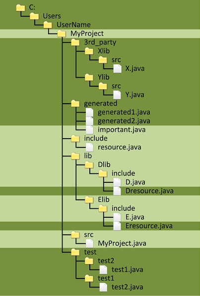

Source code elements in the files marked with darker background will not be considered when creating the results of the analysis.

**-runAndroidHunter**

This parameter turns on or off the AndroidHunter module. With this feature, SourceMeter lists Android specific coding rule violations. This module checks the Java sources of the Android projects for common Android specific faults and anti-patterns. Its value can be “true” (turn this feature on) or “false” (turn this feature off). The default value is “true”.

**-runMetricHunter**

This parameter turns on or off the MetricHunter module. With this feature, SourceMeter lists metric threshold violations. Its value can be “true” (turn this feature on) or “false” (turn this feature off). The default value is “true”.

**-runVulnerabilityHunter**

This parameter turns on or off the VulnerabilityHunter module. With this feature, SourceMeter can detect OWASP security vulnerabilities in Java web applications. Its value can be “true” (turn this feature on) or “false” (turn this feature off). The default value is “true”.

**-runFaultHunter**

This parameter turns on or off the FaultHunter module. With this feature, SourceMeter identifies common Java coding rule violations in the code (so-called bad practices) in a similar way as provided by the PMD tool. Its value can be “true” (turn this feature on) or “false” (turn this feature off). The default value is “true”.

**-runRTEHunter**

This parameter turns on or off the RTEHunter module. SourceMeter can detect runtime exception issues in Java applications. Its value can be "true" (turn this feature on) or "false" (turn this feature off). The default value is "true""

**-runDCF**

This parameter turns on or off the DuplicatedCodeFinder module. With this feature, SourceMeter identifies copy-pasted code fragments. Its value can be “true” (turn this feature on) or “false” (turn this feature off). The default value is “true”.

**-runMET**

This parameter turns on or off the Metric module. With this feature, SourceMeter computes source code metrics. Its value can be “true” (turn this feature on) or “false” (turn this feature off). The default value is “true”.

**-profileXML**

Global configuration file for SourceMeter. Its *tool-options* tag can be used to override the default metric thresholds for the MetricHunter tool or define custom metric formulas for the UserDefinedMetrics tool. Furthermore, its *rule-options* tag can enable/disable or modify the priorities of multiple rules. An example profile xml file is shown below:

```xml
      <sourcemeter-profile>
        <tool-options>
          <tool name = "MetricHunter" enabled = "true">
              <metric-thresholds>
                  <threshold metric-id="LOC" relation="gt" value="100" entity="Method" />
                  <threshold metric-id="LLOC" relation="gt" value="none" entity="Method" />
                  <threshold metric-id="NUMPAR" relation="gt" value="43" entity="Method" />
                  <threshold metric-id="TLOC" relation="gt" value="-32" entity="Method" />
              </metric-thresholds>
          </tool>
        </tool-options>

        <rule-options>
          <rule id="ECB" name="Empty Catch Block" priority="Critical" enabled="false"/>
          <rule id="AFLV" name="Avoid Final Local Variable" priority="Major" enabled="true"/>
        </rule-options>
      </sourcemeter-profile>
```

**-runUDM**

This parameter turns on or off the UserDefinedMetrics module. With this feature, SourceMeter computes custom source code metrics based on other, previously computed metrics. Its value can be “true” (turn this feature on) or “false” (turn this feature off). The default value is dependent on the presence of custom metric definitions in the profile xml.

**-rulesCSV**

There are certain rule violations that are computed by more than one tool. E.g. ADLIBDC (Avoid Decimal Literals In BigDecimal Constructor) is checked by both SpotBugs and PMD. In these cases, in order to avoid duplications, there is a priority order among the tools. This parameter can be used to override these default priorizations by specifying a .csv file in the following format:

```
      toolId;FH;AH;VH;FB;PMD
      ...
      ADLIBDC;-;-;-;1;2
      ADNIS;1;-;-;-;2
      ADS;-;-;-;-;1
      AEAI;-;-;-;-;1
      ...
```

**-cloneGenealogy**

This parameter turns on or off the tracking of code clones (copy-pasted source code fragments) through the consecutive revisions of the software system. It is required that during the analysis of the different revisions, the values set to projectName and resultsDir remain the same, so SourceMeter will handle them as different revisions of the same system. Its value can be “true” (turn this feature on) or “false” (turn this feature off). The default value is “false”.

**-cloneMinLines**

This parameter sets the minimum required size of each duplication in lines of code. The default value is 10.

**-csvSeparator**

This parameter sets the separator character in the CSV outputs. The default value is the comma (“,”). The character set here must be placed in quotation marks (e.g. -csvSeparator=“;”). Tabulator character can be set by the special “\t” value.

**-csvDecimalMark**

This parameter sets the decimal mark character in the CSV outputs. The default is value is the dot (“.”). The character set here must be placed in quotation marks (e.g. -csvDecimalMark=“,”).

**-sarifseverity**

This parameter sets the severity levels to be saved in the SARIF output. (1 - Info, 2 - Minor, 3 - Major, 4 - Critical, 5 - Blocker, c/C - CloneClass). The value should not be placed in quotation marks (e.g. -sarifseverity=2345c). The default value is 2345c.

**-maximumThreads**

This parameter sets the maximum number of parallel tasks the controller can start. The default value is the number of available CPU cores on the current system.

**-currentDate**

The name of the directory with date inside the result directory of the project. If it is not set, then the current date is used.

**-cleanResults**

Cleans all but the last n number of timestamped result directory of the current project.

**-cleanProject**

Removes all files (from the directory set by the projectBaseDir parameter) created during the analysis (.ljsi, .fjsi files in the .columbus_java directories), but does not remove anything from the results directory (resultsDir). Its value can be “true” (turn this feature on, setting projectBaseDir is mandatory in this case) or “false” (turn this feature off). The default value is “false”.

**-projectBaseDir**

Directory of the source code to be analyzed specified with relative or absolute path. Using this option the directory analysis mode will be activated. Setting projectBaseDir is mandatory.

**-javacOptions**

In directory analysis mode, the necessary parameters for compilation can be set with this option, like classpath for instance (e.g. -javacOptions=“-cp .;mydir/classpath”[^3]). The classpath given by this option is added to the auxiliary classpath of the PMD as well.

**-JVMOptions**

Extra parameters can be added for the JVM used by SourceMeter. For instance the maximum available memory of the JVM can be set manually if the default value (1/4 of the physical memory) is not enough.

**-VHMaxDepth**

The VulnerabilityHunter module checks every execution path from the “source” methods up to a specific distance in order to check if the tainted data can reach any “sink” method. The distance is set automatically by the complexity of the source code. This automatic value is good for the majority of the projects, but there are some special cases when the automatic value is not appropriate, which can lead to long execution times. In these cases, the distance can be set manually. The automatic distance limit is always logged in the VulnerabilityHunter.log file in the log directory.

**-VHTimeOut**

Time-limit for the VulnerabilityHunter module in minutes. Since the number of the possible execution path of a program can be extremely large, the run-time of VulnerabilityHunter can also be long. In order to avoid these cases either the searhing distance can be set to a properly low value or the execution time can be limited. The default time-limit is set to 60 minutes but it can be provided manually as well. If the time-limit is reached, then the searching will stop and the number of the checked “source” methods will be written into the VulnerabilityHunter.log file in the log directory. If the value is set to 0 (zero), VulnerabilityHunter runs until it examines the whole project.

**-RHMaxState**

State number limit for the RTEHunter module. The default value is 500.

**-RHMaxDepth**

State tree depth limit for the RTEHunter module. The default value is 200.

**-runFB**

This parameter turns on or off the SpotBugs coding rule violation checking. With this feature, SourceMeter lists coding rule violations detected by SpotBugs. Its value can be “true” (turn this feature on) or “false” (turn this feature off). The default value is “true”. Currently, SpotBugs is invoked only in the case of Directory analysis mode. The FBFileList parameter has to be provided.

**-FBFileList**

List file with binary inputs (class or jar files). If it is set then SourceMeter lists coding rule violations detected by the SpotBugs tool. The given Java binaries have to be compiled with debug information.

**-FBOptions**

Extra command line parameters for SpotBugs can be set with this option. For instance if some auxiliary classes are needed, these can be set by adding the -FBOptions=“-auxclasspath external.jar” option.

**-runPMD**

This parameter turns on or off the PMD coding rule violation checking. With this feature, SourceMeter lists coding rule violations detected by PMD, such as unused variables, empty catch blocks, etc. Its value can be “true” (turn this feature on) or “false” (turn this feature off). The default value is “true”.

**-pmdOptions**

In directory analysis mode, the necessary parameters required by PMD can be set with this option, like the version or encoding for instance (e.g. -pmdOptions=“-version 1.4 -encoding UTF-8”).

**-runSQ**

Import issues from SonarQube server.

**-SQHost**

The URL address of the SonarQube server.

**-SQPort**

The port of the SonarQube server.

**-SQProjectKey**

The key of the project in the SonarQube server.

**-SQProjectPrefix**

Prefix path of the project’s base directory (the path of the sonar-project.properties file).

**-SQUserName**

The user name for the SonarQube server.

**-SQPassword**

The password for the SonarQube server.

**-SQLanguageKey**

The key of the language in SonarQube.

# Usage

It can be used by simply invoking it on the directory, which contains the source files.

Execute the following command to analyze the source code of a software system:

Example (Windows):

```
SourceMeterJava -projectName=MyProject -projectBaseDir=MyProjectDir
-resultsDir=Results -runFB=true -FBFileList=filelist.txt
```

Example (Linux):

```
SourceMeterJava -projectName=MyProject -projectBaseDir=MyProjectDir
-resultsDir=Results -runFB=true -FBFileList=filelist.txt
```

If the directory does not contain all the source files or it uses already compiled binaries (.class files), then the precise analysis might require the compilation parameters of the standard javac Java compiler.

Example (Windows):

```
SourceMeterJava -projectName=MyProject -projectBaseDir=MyProjectDir
-resultsDir=Results -javacOptions="-cp .;..\\..\\classes"
```

Example (Linux):

```
SourceMeterJava -projectName=MyProject -projectBaseDir=MyProjectDir
-resultsDir=Results -javacOptions="-cp .:../../classes"
```

where “../../classes” is the directory of the class files needed for compilation.

# Result files

If any problems occur in the execution of the tools of the SourceMeter package during the code analysis, SourceMeter returns with error code 1. The error code of the given tool appears on the screen (detailed information on the bug can be found in the log directory), and the analysis is stopped, but the result files created until the failure are not deleted.

An error-free execution of SourceMeter produces the following files:

- Files containing the results of the static analysis in the results directory (set by the resultsDir parameter):
  - $(projectName)\java\$(DATE)\$(projectName)-*.csv

    CSV (comma separated values) files containing different metrics: Component, File, Package, Class, Interface, Enum, Method, Attribute, and Annotation level source code metrics, rule violation counts, and clone-related metrics at CloneClass and CloneInstance level.
  - $(projectName)\java\$(DATE)\$(projectName)-clones.txt

    List of the code clones (copy-pasted source code fragments) in the system.
  - $(projectName)\java\$(DATE)\$(projectName)-MetricHunter.txt

    List of the MetricHunter metric value violations in the system.
  - $(projectName)\java\$(DATE)\$(projectName)-FaultHunter.txt

    List of the FaultHunter coding rule violations in the system.
  - $(projectName)\java\$(DATE)\$(projectName)-AndroidHunter.txt

    List of the AndroidHunter coding rule violations in the system.
  - $(projectName)\java\$(DATE)\$(projectName)-VulnerabilityHunter.txt

    List of the vulnerabilities in the system.
  - $(projectName)\java\$(DATE)\$(projectName)-RTEHunter.txt

    List of the RTEHunter coding rule violations in the system.
  - $(projectName)\java\$(DATE)\$(projectName)-PMD.txt

    List of the PMD coding rule violations in the system.
  - $(projectName)\java\$(DATE)\$(projectName)-FindBugs.txt

    List of the SpotBugs coding rule violations in the system.
  - $(projectName)\java\$(DATE)\$(projectName).graph

    Binary representation of the result graph containing all the metrics, code clones and coding rule violations.
  - $(projectName)\java\$(DATE)\$(projectName).xml

    XML representation of the result graph containing all the metrics, code clones and coding rule violations.
  - $(projectName)\java\$(projectName).gsi

    Binary data file containing information for tracking the code clones through the consecutive revisions of the analyzed software system.
  - $(projectName)\java\$(DATE)\$(projectName).sarif

    SARIF representation of the rule violations.
  - $(projectName)\java\$(DATE)\$(projectName)-summary.graph

    Binary representation of the summary result graph containing only the System component node.
  - $(projectName)\java\$(DATE)\$(projectName)-summary.xml

    XML representation of the summary result graph containing only the System component node.
  - $(projectName)\java\$(DATE)\$(projectName)-summary.json

    JSON representation of the summary result graph containing only the System component node.
- Other files and directories created in the results directory:
  - $(projectName)\java\$(DATE)\sourcemeter

    Directory, which contains configuration, binary, ASG, log, and temporary files created during the source code analysis.
  - $(projectName)\java\$(DATE)\sourcemeter\asg

    Directory, which contains backup copies of the linked ASG and LIM files, the corresponding filter files, and the GSI file.
  - $(projectName)\java\$(DATE)\sourcemeter\graph

    Directory, which contains backup copies of the graph files.
  - $(projectName)\java\$(DATE)\sourcemeter\log

    Directory, which contains the log files created during the code analysis.
  - $(projectName)\java\$(DATE)\sourcemeter\temp

    Directory, which contains the temporary files created during the code analysis.
- Files created outside the results directory:
  - .ljsi

    Linked Java language dependent ASG file. One .ljsi file is created in the .columbus_java sub-directory of the directory set by the projectBaseDir parameter.
  - .fjsi

    Filter file belonging to the linked Java language dependent ASG file (.ljsi). It is created in the corresponding directory of the .ljsi file.

It is important to note that “standard parts” are not taken into consideration while creating the results. This means that e.g. when a class does not have an explicit superclass, its number of parents (and ancestors) will be 0 (zero) despite the fact that every Java class inherits implicitly from Object, which would suggest that the number will be 1. Similarly, other metrics and results also disregard “standard parts”.

# Coding rule violation suppression

The warnings issued by the rule checker modules can be suppressed in case they are found to be invalid or for any other reason. In the case of the integrated 3<sup>rd</sup> party tools (PMD, SpotBugs) the warnings can be suppressed with their own official warning suppression mechanisms. In case of SourceMeter coding issue checker modules this can be done either by using the SuppressWarnings annotation with “NOSM” or by marking the code line of the warning with a special one-line comment with the same “NOSM” string. In case of the SuppressWarnings annotation, warnings will be suppressed in every line of the annotated element.

Example:

```java
@SuppressWarnings("NOSM")
public class Foo {

  @SuppressWarnings("PMD")
  public void goo() {
  }

}
```

In this example, all SourceMeter warnings are suppressed in the class “Foo” and all PMD warnings in the method “goo”.

Example:

```java
public class Foo {

  public void bar() {
    try {

    } catch (Exception e) { // NOSM

    }
  }
}
```

Due to the warning suppressor marker, the “Empty Catch Block” warning will not be issued.

The warnings of the MetricHunter module cannot be suppressed at the moment.

# Demo

The Demo directory of the installation package contains the directory structure, the build and analyzer scripts for the analysis of an example project. Version 1.2.17 of the log4j open source program are included as example projects, which can also be downloaded from the following URLs:

http://archive.apache.org/dist/logging/log4j/1.2.17/log4j-1.2.17.zip

To perform the source code analysis of the demo project, one of the analyze-dir.bat/analyze-dir.sh scripts has to be executed.

Contents of the Demo directory:

Windows:

| Demo\ |  |  |
| --- | --- | --- |
|  | apache-log4j-1.2.17 | # source code of log4j version 1.2.17 |
|  | analyze-dir.bat | # starts SourceMeter in Directory analysis mode |

Linux:

| Demo/ |  |  |
| --- | --- | --- |
|  | apache-log4j-1.2.17 | # source code of log4j version 1.2.17 |
|  | analyze-dir.sh | # starts SourceMeter in Directory analysis mode |

# Error messages

- Message: There is no valid license!

  Solution: Install a valid license key file (see Installation section).
- Message: Please set the resultsDir parameter. Under this directory a new directory with the name of the analyzed project will be created, if it does not exist yet. All results will be stored there under separate directories with their names containing the date and time.

  Solution: The resultsDir parameter must be set.
- Message: Please set the projectName parameter to the name of the analyzed software system.

  Solution: The projectName parameter must be set.
- Message: Please set the projectBaseDir parameter.

  Solution: The projectBaseDir parameters must be set.
- Message: Required java version is Java 10 or 11

  Solution: In order to use SourceMeter the installation of JDK 10 or 11 version is required, and the corresponding environment variables must be set correctly.
- Message: ASG list file does not exist: …/sourcemeter/log/superlinklist.txt

  ```
  Unable to find a javac compiler; com.sun.tools.javac.Main is not on the classpath.
  Perhaps JAVA_HOME does not point to the JDK.

  It is currently set to "c:\Program Files\Java\jre7"
  ```

- Message: exec returned: 255

  If any of the log files in the the $(projectName)\$(DATE)\sourcemeter\log directory starts with “Could not load a transcoding service”, then the GCONV_PATH should be set to the current gconv directory. Check the “Requirements” section of the user’s guide.

# Known bugs and deficiencies

Known bugs and deficiencies of SourceMeter for Java.

- Regarding the computation of most of the metrics the init and static init blocks of Java classes, and lambdas are not taken into consideration.
- SourceMeter places the results into the directory specified by the projectName parameter. If special characters (like ‘<’, ‘>’, etc.) are used in the parameter, the analysis will probably fail.

# FAQ

Frequently Asked Questions regarding SourceMeter.

- Problem: On Windows platforms, in case of deep directory hierarchies, it may happen that the full paths of some files exceed 259 characters. In this case some SourceMeter tools may have problems with opening these files; they will terminate and write appropriate messages in the logs.

  Solution: Move the files to be analyzed to a directory closer to the file system root, or use the ‘subst’ shell command.

# Appendices

## Reference of source code metrics

Source code metrics are used to quantify different source code characteristics. FrontEndART SourceMeter computes source code metrics for the following source code element kinds: components (e.g. archives), source files, packages, class types (including classes, interfaces, enums and annotations) and methods.

The calculated metrics are grouped into 6 categories, which are the following:

- **Cohesion metrics:** measure to what extent the source code elements are coherent in the system.
- **Complexity metrics:** measure the complexity of source code elements (typically algorithms).
- **Coupling metrics:** measure the amount of interdependencies of source code elements.
- **Documentation metrics:** measure the amount of comments and documentation of source code elements in the system.
- **Inheritance metrics:** measure the different aspects of the inheritance hierarchy of the system.
- **Size metrics:** measure the basic properties of the analyzed system in terms of different cardinalities (e.g. number of code lines, number of classes or methods).

In the case of the documentation metrics all the comments found immediately before a source code element are considered as its documentation, while the comments contained inside the source code element are considered as its comments.

The following table summarizes the metrics, their abbreviations and their correspondence to different source code element kinds:

| Category | Metric name | Abbreviation | Annotation | Class | Component | Enum | File | Interface | Method | Package |
| --- | --- | --- | --- | --- | --- | --- | --- | --- | --- | --- |
| Cohesion metrics | Lack of Cohesion in Methods 5 | LCOM5 | X | X |  | X |  | X |  |  |
| Complexity metrics | Halstead Calculated Program Length | HCPL |  |  |  |  |  |  | X |  |
|  | Halstead Difficulty | HDIF |  |  |  |  |  |  | X |  |
|  | Halstead Effort | HEFF |  |  |  |  |  |  | X |  |
|  | Halstead Number of Delivered Bugs | HNDB |  |  |  |  |  |  | X |  |
|  | Halstead Program Length | HPL |  |  |  |  |  |  | X |  |
|  | Halstead Program Vocabulary | HPV |  |  |  |  |  |  | X |  |
|  | Halstead Time Required to Program | HTRP |  |  |  |  |  |  | X |  |
|  | Halstead Volume | HVOL |  |  |  |  |  |  | X |  |
|  | Maintainability Index (Microsoft version) | MIMS |  |  |  |  |  |  | X |  |
|  | Maintainability Index (Original version) | MI |  |  |  |  |  |  | X |  |
|  | Maintainability Index (SEI version) | MISEI |  |  |  |  |  |  | X |  |
|  | Maintainability Index (SourceMeter version) | MISM |  |  |  |  |  |  | X |  |
|  | McCabe’s Cyclomatic Complexity | McCC |  |  |  |  | X |  | X |  |
|  | Nesting Level | NL | X | X |  | X |  | X | X |  |
|  | Nesting Level Else-If | NLE | X | X |  | X |  | X | X |  |
|  | Weighted Methods per Class | WMC | X | X |  | X |  | X |  |  |
| Coupling metrics | Coupling Between Object classes | CBO | X | X |  | X |  | X |  |  |
|  | Coupling Between Object classes Inverse | CBOI | X | X |  | X |  | X |  |  |
|  | Number of Incoming Invocations | NII | X | X |  | X |  | X | X |  |
|  | Number of Outgoing Invocations | NOI | X | X |  | X |  | X | X |  |
|  | Response set For Class | RFC | X | X |  | X |  | X |  |  |
| Documentation metrics | API Documentation | AD | X | X |  | X |  | X |  | X |
|  | Comment Density | CD | X | X |  | X |  | X | X | X |
|  | Comment Lines of Code | CLOC | X | X |  | X | X | X | X | X |
|  | Documentation Lines of Code | DLOC | X | X |  | X |  | X | X |  |
|  | Public Documented API | PDA | X | X |  | X | X | X |  | X |
|  | Public Undocumented API | PUA | X | X |  | X | X | X |  | X |
|  | Total API Documentation | TAD |  |  | X |  |  |  |  | X |
|  | Total Comment Density | TCD | X | X | X | X |  | X | X | X |

[output cut: 52 more lines]

### Cohesion metrics

#### Lack of Cohesion in Methods 5 (LCOM5)

**Class:** number of functionalities of the class. One of the basic principles of object-oriented programming is encapsulation, meaning that attributes belonging together and the operations that use them should be organized into one class, and one class shall implement only one functionality, i.e. its attributes and methods should be coherent. This metric measures the lack of cohesion and computes into how many coherent classes the class could be split. It is calculated by taking a non-directed graph, where the nodes are the implemented local methods of the class and there is an edge between the two nodes if and only if a common (local or inherited) attribute or abstract method is used or a method invokes another. The value of the metric is the number of connected components in the graph not counting those, which contain only constructors, destructors, getters, or setters.

### Complexity metrics

#### Halstead Calculated Program Length (HCPL)

**Method:**

- *n1*: number of distinct operators (semantic meanings of the reserved keywords, semicolons, blocks, and identifiers except in their declarations)
- *n2*: number of distinct operands (literals - e.g. character, string, and integer literals, - and the identifiers in their declarations)

The calculated program length is *n1 * log<sub>2</sub>(n1) + n2 * log<sub>2</sub>(n2)*.

#### Halstead Difficulty (HDIF)

**Method:**

- *n1*: number of distinct operators (semantic meanings of the reserved keywords, semicolons, blocks, and identifiers except in their declarations)
- *n2*: number of distinct operands (literals - e.g. character, string, and integer literals, - and the identifiers in their declarations)
- *N2*: total number of operands

The Halstead difficulty is *n1/2 * N2/n2*.

#### Halstead Effort (HEFF)

**Method:**

- *n1*: number of distinct operators (semantic meanings of the reserved keywords, semicolons, blocks, and identifiers except in their declarations)
- *n2*: number of distinct operands (literals - e.g. character, string, and integer literals, - and the identifiers in their declarations)
- *N1*: total number of operators
- *N2*: total number of operands
- *n : n1 + n2* (program vocabulary)
- *N : N1 + N2* (program length)
- *V : N * log<sub>2</sub>(n)* (volume)
- *D : n1/2 * N2/n2* (difficulty)

The Halstead effort is *D * V*.

#### Halstead Number of Delivered Bugs (HNDB)

**Method:**

- *n1*: number of distinct operators (semantic meanings of the reserved keywords, semicolons, blocks, and identifiers except in their declarations)
- *n2*: number of distinct operands (literals - e.g. character, string, and integer literals, - and the identifiers in their declarations)
- *N1*: total number of operators
- *N2*: total number of operands
- *n : n1 + n2* (program vocabulary)
- *N : N1 + N2* (program length)
- *V : N * log<sub>2</sub>(n)* (volume)
- *D : n1/2 * N2/n2* (difficulty)
- *E : D * V* (effort)

Number of delivered bugs is *E<sup>2/3</sup>/3000*.

#### Halstead Program Length (HPL)

**Method:**

- *N1*: total number of operators (semantic meanings of the reserved keywords, semicolons, blocks, and identifiers except in their declarations)
- *N2*: total number of operands (literals - e.g. character, string, and integer literals, - and the identifiers in their declarations)

Halstead program length is *N1 + N2*.

#### Halstead Program Vocabulary (HPV)

**Method:**

- *n1*: number of distinct operators (semantic meanings of the reserved keywords, semicolons, blocks, and identifiers except in their declarations)
- *n2*: number of distinct operands (literals - e.g. character, string, and integer literals, - and the identifiers in their declarations)

Halstead program vocabulary is *n1 + n2*.

#### Halstead Time Required to Program (HTRP)

**Method:**

- *n1*: number of distinct operators (semantic meanings of the reserved keywords, semicolons, blocks, and identifiers except in their declarations)
- *n2*: number of distinct operands (literals - e.g. character, string, and integer literals, - and the identifiers in their declarations)
- *N1*: total number of operators
- *N2*: total number of operands
- *n : n1 + n2* (program vocabulary)
- *N : N1 + N2* (program length)
- *V : N * log<sub>2</sub>(n)* (volume)
- *D : n1/2 * N2/n2* (difficulty)
- *E : D * V* (effort)

Halstead time required to program is *E/18* seconds.

#### Halstead Volume (HVOL)

**Method:**

- *n1*: number of distinct operators (semantic meanings of the reserved keywords, semicolons, blocks, and identifiers except in their declarations)
- *n2*: number of distinct operands (literals - e.g. character, string, and integer literals, - and the identifiers in their declarations)
- *N1*: total number of operators
- *N2*: total number of operands
- *n : n1 + n2* (program vocabulary)
- *N : N1 + N2* (program length)

The Halstead volume is *N * log<sub>2</sub>(n)*.

#### Maintainability Index (Microsoft version) (MIMS)

- *HVOL*: Halstead Volume
- *McCC*: McCabe’s cyclomatic complexity
- *LLOC*: logical lines of code

The Maintainability Index used by Microsoft’s Visual Studio is computed by the following formula:

*MIMS = max(0,(171 - 5.2 * ln(HVOL) - 0.23 * (McCC) - 16.2 * ln(LLOC)) * 100 / 171)*

#### Maintainability Index (Original version) (MI)

- *HVOL*: Halstead Volume
- *McCC*: McCabe’s cyclomatic complexity
- *LLOC*: logical lines of code

The original Maintainability Index is computed by the following formula:

*MI = 171 - 5.2 * ln(HVOL) - 0.23 * (McCC) - 16.2 * ln(LLOC)*

#### Maintainability Index (SEI version) (MISEI)

- *HVOL*: Halstead Volume
- *McCC*: McCabe’s cyclomatic complexity
- *LLOC*: logical lines of code
- *CD*: comment density

The Maintainability Index derived by the Software Engineering Institute (SEI) is computed by the following formula:

*MISEI = 171 - 5.2 * log<sub>2</sub>(HVOL) - 0.23 * McCC - 16.2 * log<sub>2</sub>(LLOC) + 50 * sin(sqrt(2.4 * CD))*

#### Maintainability Index (SourceMeter version) (MISM)

- *HVOL*: Halstead Volume
- *McCC*: McCabe’s cyclomatic complexity
- *LLOC*: logical lines of code
- *CD*: comment density

The Maintainability Index proposed by SourceMeter combines the different scaling approach from Microsoft’s version with the inclusion of comment percentage from the Software Engineering Institute (SEI) version into the following formula:

*MISM = max(0, (171 - 5.2 * log<sub>2</sub>(HVOL) - 0.23 * McCC - 16.2 * log<sub>2</sub>(LLOC) + 50 * sin(sqrt(2.4 * CD))) * 100 / 171)*

#### McCabe’s Cyclomatic Complexity (McCC)

**Method:** complexity of the method expressed as the number of independent control flow paths in it. It represents a lower bound for the number of possible execution paths in the source code and at the same time it is an upper bound for the minimum number of test cases needed for achieving full branch test coverage. The value of the metric is calculated as the number of the following instructions plus 1: if, for, foreach, while, do-while, case label (which belongs to a switch instruction), catch, conditional statement (?:). Moreover, logical “and” (&&) and logical “or” (||) expressions also add 1 to the value because their short-circuit evaluation can cause branching depending on the first operand. The following instructions are not included: else, switch, default label (which belongs to a switch instruction), try, finally.

**File:** complexity of the file expressed as the number of independent control flow paths in it. It is calculated as the sum of the McCabe’s Cyclomatic Complexity values of the methods can be found in the file.

#### Nesting Level (NL)

**Method:** complexity of the method expressed as the depth of the maximum embeddedness of its conditional, iteration and exception handling block scopes. The following instructions are taken into account: if, else-if, else, for, while, do-while, switch, try, catch, finally and block statements that are directly inside another block statement. The following instructions do not increase the value by themselves; however, if additional embeddednesses can be found in their blocks, they are considered: case and default label (which belong to a switch instruction).

**Class:** complexity of the class expressed as the depth of the maximum embeddedness of its conditional, iteration and exception handling block scopes. It is calculated as the maximum nesting level (NL) of its local methods and init blocks.

#### Nesting Level Else-If (NLE)

**Method:** complexity of the method expressed as the depth of the maximum embeddedness of its conditional, iteration and exception handling block scopes, where in the if-else-if construct only the first if instruction is considered. The following instructions are taken into account: if, else, for, while, do-while, switch, try, catch, finally and block statements that are directly inside another block statement. The following instructions do not increase the value by themselves; however, if additional embeddednesses can be found in their blocks, they are considered: else-if (i.e. in the if-else-if construct the use of else-if does not increase the value of the metric), case and default label (which belong to a switch instruction).

**Class:** complexity of the class expressed as the depth of the maximum embeddedness of its conditional, iteration and exception handling block scopes, where in the if-else-if construct only the first if instruction is considered. It is calculated as the maximum nesting level (NLE) of its local methods and init blocks.

#### Weighted Methods per Class (WMC)

**Class:** complexity of the class expressed as the number of independent control flow paths in it. It is calculated as the sum of the McCabe’s Cyclomatic Complexity (McCC) values of its local methods and init blocks.

### Coupling metrics

#### Coupling Between Object classes (CBO)

**Class:** number of directly used other classes (e.g. by inheritance, function call, type reference, attribute reference). Classes using many other classes highly depend on their environment, so it is difficult to test or reuse them; furthermore, they are very sensitive to the changes in the system.

#### Coupling Between Object classes Inverse (CBOI)

**Class:** number of other classes, which directly use the class. Classes which are used by many other classes have a high impact on the behavior of the system, and should be modified very carefully and tested intensively.

#### Number of Incoming Invocations (NII)

**Method:** number of other methods and attribute initializations which directly call the method. If the method is invoked several times from the same method or attribute initialization, it is counted only once.

**Class:** number of other methods and attribute initializations which directly call the local methods of the class. If a method is invoked several times from the same method or attribute initialization, it is counted only once.

#### Number of Outgoing Invocations (NOI)

**Method:** number of directly called methods. If a method is invoked several times, it is counted only once.

**Class:** number of directly called methods of other classes, including method invocations from attribute initializations. If a method is invoked several times, it is counted only once.

#### Response set For Class (RFC)

**Class:** number of local (i.e. not inherited) methods in the class (NLM) plus the number of directly invoked other methods by its methods or attribute initializations (NOI).

### Documentation metrics

#### API Documentation (AD)

**Class:** ratio of the number of documented public methods in the class +1 if the class itself is documented to the number of all public methods in the class + 1 (the class itself); however, the nested, anonymous, and local classes are not included.

**Package:** ratio of the number of documented public classes and methods in the package to the number of all of its public classes and methods; however, the classes and methods of its subpackages are not included.

#### Comment Density (CD)

**Method:** ratio of the comment lines of the method (CLOC) to the sum of its comment (CLOC) and logical lines of code (LLOC).

**Class**: ratio of the comment lines of the class (CLOC) to the sum of its comment (CLOC) and logical lines of code (LLOC).

**Package:** ratio of the comment lines of the package (CLOC) to the sum of its comment (CLOC) and logical lines of code (LLOC).

#### Comment Lines of Code (CLOC)

**Method**: number of comment and documentation code lines of the method; however, its anonymous and local classes are not included.

**Class:** number of comment and documentation code lines of the class, including its local methods and attributes; however, its nested, anonymous, and local classes are not included.

**File:** number of comment and documentation code lines of the file.

**Package:** number of comment and documentation code lines of the package; however, its subpackages are not included.

#### Documentation Lines of Code (DLOC)

**Method**: number of documentation code lines of the method.

**Class:** number of documentation code lines of the class, including its local methods and attributes; however, its nested, anonymous, and local classes are not included.

#### Public Documented API (PDA)

**Class:** number of documented public methods in the class (+1 if the class itself is documented); however, the methods of its nested, anonymous, and local classes are not counted.

**File:** number of documented public classes and methods in the file.

**Package:** number of documented public classes and methods in the package; however, the classes and methods of its subpackages are not counted.

#### Public Undocumented API (PUA)

**Class:** number of undocumented public methods in the class (+1 if the class itself is undocumented); however, the methods of its nested, anonymous, and local classes are not counted.

**File:** number of undocumented public classes and methods in the file.

**Package:** number of undocumented public classes and methods in the package; however, the classes and methods of its subpackages are not counted.

#### Total API Documentation (TAD)

**Package:** ratio of the number of documented public classes and methods in the package to the number of all of its public classes and methods, including its subpackages.

**Component:** ratio of the number of documented public classes and methods in the component to the number of all of its public classes and methods, including its subcomponents.

#### Total Comment Density (TCD)

**Method:** ratio of the total comment lines of the method (TCLOC) to the sum of its total comment (TCLOC) and total logical lines of code (TLLOC).

**Class:** ratio of the total comment lines of the class (TCLOC) to the sum of its total comment (TCLOC) and total logical lines of code (TLLOC).

**Package:** ratio of the total comment lines of the package (TCLOC) to the sum of its total comment (TCLOC) and total logical lines of code (TLLOC).

**Component:** ratio of the total comment lines of the component (TCLOC) to the sum of its total comment (TCLOC) and total logical lines of code (TLLOC).

#### Total Comment Lines of Code (TCLOC)

**Method**: number of comment and documentation code lines of the method, including its anonymous and local classes.

**Class:** number of comment and documentation code lines of the class, including its local methods and attributes, as well as its nested, anonymous, and local classes.

**Package:** number of comment and documentation code lines of the package, including its subpackages.

**Component:** number of comment and documentation code lines of the component, including its subcomponents.

#### Total Public Documented API (TPDA)

**Package:** number of documented public classes and methods in the package, including the documented public classes and methods of its subpackages.

**Component:** number of documented public classes and methods in the component, including the documented public classes and methods of its subcomponents.

#### Total Public Undocumented API (TPUA)

**Package:** number of undocumented public classes and methods in the package, including the undocumented public classes and methods of its subpackages.

**Component:** number of undocumented public classes and methods in the component, including the undocumented public classes and methods of its subcomponents.

### Inheritance metrics

#### Depth of Inheritance Tree (DIT)

**Class:** length of the path that leads from the class to its farthest ancestor in the inheritance tree.

#### Number of Ancestors (NOA)

**Class:** number of classes, interfaces, enums and annotations from which the class is directly or indirectly inherited.

#### Number of Children (NOC)

**Class:** number of classes, interfaces, enums and annotations which are directly derived from the class.

#### Number of Descendants (NOD)

**Class:** number of classes, interfaces, enums, annotations, which are directly or indirectly derived from the class.

#### Number of Parents (NOP)

**Class:** number of classes, interfaces, enums and annotations from which the class is directly inherited.

### Size metrics

#### Lines of Code (LOC)

**Method**: number of code lines of the method, including empty and comment lines; however, its anonymous and local classes are not included.

**Class:** number of code lines of the class, including empty and comment lines, as well as its local methods; however, its nested, anonymous, and local classes are not included.

**File:** number of code lines of the file.

**Package:** number of code lines of the package, including empty and comment lines; however, its subpackages are not included.

#### Logical Lines of Code (LLOC)

**Method:** number of non-empty and non-comment code lines of the method; however, its anonymous and local classes are not included.

**Class:** number of non-empty and non-comment code lines of the class, including the non-empty and non-comment lines of its local methods; however, its nested, anonymous, and local classes are not included.

**File:** number of non-empty and non-comment code lines of the file.

**Package:** number of non-empty and non-comment code lines of the package; however, its subpackages are not included.

#### Number of Attributes (NA)

**Class:** number of attributes in the class, including the inherited ones; however, the attributes of its nested, anonymous, and local classes are not included.

**Package:** number of attributes in the package; however, attributes of its subpackages are not included.

#### Number of Classes (NCL)

**Package:** number of classes in the package; however, the classes of its subpackages are not included.

#### Number of Enums (NEN)

**Package:** number of enums in the package; however, the enums of its subpackages are not included.

#### Number of Getters (NG)

**Class:** number of getter methods in the class, including the inherited ones; however, the getter methods of its nested, anonymous, and local classes are not included. Methods that override abstract methods are not counted.

**Package**: number of getter methods in the package; however, getter methods of its subpackages are not included.

#### Number of Interfaces (NIN)

**Package:** number of interfaces in the package; however, the interfaces of its subpackages are not included.

#### Number of Local Attributes (NLA)

**Class:** number of local (i.e. not inherited) attributes in the class; however, the attributes of nested, anonymous, and local classes are not included.

#### Number of Local Getters (NLG)

**Class:** number of local (i.e. not inherited) getter methods in the class; however, the getter methods of its nested, anonymous, and local classes are not included. Methods that override abstract methods are not counted.

#### Number of Local Methods (NLM)

**Class:** number of local (i.e. not inherited) methods in the class; however, the methods of nested, anonymous, and local classes are not included.

#### Number of Local Public Attributes (NLPA)

**Class:** number of local (i.e. not inherited) public attributes in the class; however, the attributes of nested, anonymous, and local classes are not included.

#### Number of Local Public Methods (NLPM)

**Class:** number of local (i.e. not inherited) public methods in the class; however, the methods of nested, anonymous, and local classes are not included.

#### Number of Local Setters (NLS)

**Class:** number of local (i.e. not inherited) setter methods in the class; however, the setter methods of its nested, anonymous, and local classes are not included. Methods that override abstract methods are not counted.

#### Number of Methods (NM)

**Class:** number of methods in the class, including the inherited ones; however, the methods of its nested, anonymous and local classes are not included. Methods that override abstract methods are not counted.

**Package:** number of methods in the package; however, methods of its subpackages are not included.

#### Number of Packages (NPKG)

**Package:** number of directly contained subpackages of the package.

#### Number of Parameters (NUMPAR)

**Method**: number of the parameters of the method. The varargs parameter counts as one.

#### Number of Public Attributes (NPA)

**Class:** number of public attributes in the class, including the inherited ones; however, the public attributes of its nested, anonymous, and local classes are not included.

**Package:** number of public attributes in the package; however, the public attributes of its subpackages are not included.

#### Number of Public Methods (NPM)

**Class:** number of public methods in the class, including the inherited ones; however, the public methods of nested, anonymous, and local classes are not included. Methods that override abstract methods are not counted.

**Package:** number of public methods in the package; however, the public methods of its subpackages are not included.

#### Number of Setters (NS)

**Class:** number of setter methods in the class, including the inherited ones; however, the setter methods of its nested, anonymous, and local classes are not included. Methods that override abstract methods are not counted.

**Package:** number of setter methods in the package; however, setter methods of its subpackages are not included.

#### Number of Statements (NOS)

**Method:** number of statements in the method; however, the statements of its anonymous and local classes are not included.

**Class:** number of statements in the class; however, the statements of its nested, anonymous, and local classes are not included.

#### Total Lines of Code (TLOC)

**Method**: number of code lines of the method, including empty and comment lines, as well as its anonymous and local classes.

**Class:** number of code lines of the class, including empty and comment lines, as well as its local methods, anonymous, local, and nested classes.

**Package:** number of code lines of the package, including empty and comment lines, as well as its subpackages.

**Component:** number of code lines of the component, including empty and comment lines, as well as its subcomponents.

#### Total Logical Lines of Code (TLLOC)

**Method**: number of non-empty and non-comment code lines of the method, including the non-empty and non-comment lines of its anonymous and local classes.

**Class:** number of non-empty and non-comment code lines of the class, including the non-empty and non-comment code lines of its local methods, anonymous, local, and nested classes.

**Package:** number of non-empty and non-comment code lines of the package, including its subpackages.

**Component:** number of non-empty and non-comment code lines of the component, including its subcomponents.

#### Total Number of Attributes (TNA)

**Class:** number of attributes in the class, including the inherited ones, as well as the inherited and local attributes of its nested, anonymous and local classes.

**Package:** number of attributes in the package, including the attributes of its subpackages.

**Component:** number of attributes in the component, including the attributes of its subcomponents.

#### Total Number of Classes (TNCL)

**Package:** number of classes in the package, including the classes of its subpackages.

**Component:** number of classes in the component, including the classes of its subcomponents.

#### Total Number of Directories[^4] (TNDI)

**Package:** number of directories that belong to the package, including the directories of its subpackages.

**Component:** number of directories that belong to the component, including its subcomponents.

#### Total Number of Enums (TNEN)

**Package:** number of enums in the package, including the enums of its subpackages.

**Component:** number of enums in the component, including the enums of its subcomponents.

#### Total Number of Files (TNFI)

**Package:** number of files that belong to the package, including the files of its subpackages.

**Component:** number of files that belong to the component, including its subcomponents.

#### Total Number of Getters (TNG)

**Class:** number of getter methods in the class, including the inherited ones, as well as the inherited and local getter methods of its nested, anonymous and local classes.

**Package:** number of getter methods in the package, including the getter methods of its subpackages.

**Component:** number of getter methods in the component, including the getter methods of its subcomponents.

#### Total Number of Interfaces (TNIN)

**Package:** number of interfaces in the package, including the interfaces of its subpackages.

**Component:** number of interfaces in the component, including the interfaces of its subcomponents.

#### Total Number of Local Attributes (TNLA)

**Class:** number of local (i.e. not inherited) attributes in the class, including the attributes of its nested, anonymous, and local classes.

#### Total Number of Local Getters (TNLG)

**Class:** number of local (i.e. not inherited) getter methods in the class, including the local getter methods of its nested, anonymous, and local classes.

#### Total Number of Local Methods (TNLM)

**Class:** number of local (i.e. not inherited) methods in the class, including the local methods of its nested, anonymous, and local classes.

#### Total Number of Local Public Attributes (TNLPA)

**Class:** number of local (i.e. not inherited) public attributes in the class, including the local public attributes of its nested, anonymous, and local classes.

#### Total Number of Local Public Methods (TNLPM)

**Class:** number of local (i.e. not inherited) public methods in the class, including the local methods of its nested, anonymous, and local classes.

#### Total Number of Local Setters (TNLS)

**Class:** number of local (i.e. not inherited) setter methods in the class, including the local setter methods of its nested, anonymous, and local classes.

#### Total Number of Methods (TNM)

**Class:** number of methods in the class, including the inherited ones, as well as the inherited and local methods of its nested, anonymous, and local classes. Methods that override abstract methods are not counted.

**Package:** number of methods in the package, including the methods of its subpackages.

**Component:** number of methods in the component, including the methods of its subcomponents.

#### Total Number of Packages (TNPKG)

**Package:** number of subpackages in the package, including all directly or indirectly contained subpackages.

**Component:** number of packages and subpackages that belong to the component, including its subcomponents.

#### Total Number of Public Attributes (TNPA)

**Class:** number of public attributes in the class, including the inherited ones, as well as the inherited and local public attributes of its nested, anonymous, and local classes.

**Package:** number of public attributes in the package, including the public attributes of its subpackages.

**Component:** number of public attributes in the component, including the public attributes of its subcomponents.

#### Total Number of Public Classes (TNPCL)

**Package:** number of public classes in the package, including the public classes of its subpackages.

**Component:** number of public classes in the component, including the public classes of its subcomponents.

#### Total Number of Public Enums (TNPEN)

**Package:** number of public enums in the package, including the public enums of its subpackages.

**Component:** number of public enums in the component, including the public enums of its subcomponents.

#### Total Number of Public Interfaces (TNPIN)

**Package:** number of public interfaces in the package, including the public interfaces of its subpackages.

**Component:** number of public interfaces in the component, including the public interfaces of its subcomponents.

#### Total Number of Public Methods (TNPM)

**Class:** number of public methods in the class, including the inherited ones, as well as the inherited and local public methods of its nested, anonymous, and local classes.

**Package:** number of public methods in the package, including the public methods of its subpackages.

**Component:** number of public methods in the component, including the public methods of its subcomponents.

#### Total Number of Setters (TNS)

**Class:** number of setter methods in the class, including the inherited ones, as well as the inherited and local setter methods of its nested, anonymous and local classes.

**Package:** number of setter methods in the package, including the setter methods of its subpackages.

**Component:** number of setter methods in the component, including the setter methods of its subcomponents.

#### Total Number of Statements (TNOS)

**Method:** number of statements in the method, including the statements of its anonymous and local classes.

**Class:** number of statements in the class, including the statements of its nested, anonymous, and local classes.

**Package:** number of statements in the package, including the statements of its subpackages.

**Component:** number of statements in the component, including the statements of its subcomponents.

## Reference of code duplication metrics

Code cloning (or copy-paste programming) means the copying of an existing piece of source code, pasting it somewhere else, and typically performing smaller modifications on it. Based on the level of similarity between the copied code fragments we can define the following duplication types:

- **Type-1**: the copied code parts are identical code fragments except for variations in whitespace, layout and comments.
- **Type-2**: syntactically identical fragments except for variations in identifier names, literals, type references, whitespace, layout and comments.
- **Type-3**: copied fragments with further modifications such as altered, added, or removed statements, in addition to variations in identifier names, literals, type references, whitespace, layout and comments.
- **Type-4**: the copied code fragments are syntactically different, but they perform the same functionality, i.e. they are semantically the same.

FrontEndART SourceMeter is capable of identifying Type-2 clones, i.e. code fragments that are structurally identical, but may differ in variable names, literals, identifiers, etc.

Two code segments correspond to each other if they are copies of each other. This relation is an equivalence relation and we use the notion of clone classes to the classes of the relation, and the members of the classes will be referred to as clone instances. Owing to the nature of the relation, each clone class must contain at least two clone instances.

Clones are tracked during the source code analysis of consecutive revisions of the analyzed software system. FrontEndART SourceMeter detects suspicious, inconsistently changing code copies, which are called “clone smells”. The smells concerning clone classes are the following:

- **Disappearing Clone Class (DCC):** The clone class existed in the previously analyzed revision but it does not exist anymore.
- **Appearing Clone Class (ACC):** The clone class did not exist in the previously analyzed revision.

The smells concerning clone instances are issued only if the containing clone class does not contain any smell. These are the following:

- **Disappearing Clone Instance (DCI):** The clone instance existed in the previously analyzed revision but it does not exist anymore.
- **Appearing Clone Instance (ACI):** The clone instance did not exist in the previously analyzed revision.
- **Moving Clone Instance (MCI):** The clone instance belonged to a different clone class in the previously analyzed revision than its current class.

The following table summarizes the code duplication metrics, their abbreviations, and their correspondence to different source code element types.

| Metric name | Abbrev. | Clone Instance | Clone Class | Method | Class | Interface | Enum | Package | Comp. |
| --- | --- | --- | --- | --- | --- | --- | --- | --- | --- |
| Clone Age | CA | X | X |  |  |  |  |  |  |
| Clone Classes | CCL |  |  | X | X | X | X | X | X |
| Clone Complexity | CCO | X | X | X | X | X | X | X | X |
| Clone Coverage | CC |  |  | X | X | X | X | X | X |
| Clone Elimination Effort | CEE |  | X |  |  |  |  |  | X |
| Clone Elimination Gain | CEG |  | X |  |  |  |  |  | X |
| Clone Embeddedness | CE | X | X |  |  |  |  |  |  |
| Clone Instances | CI |  | X | X | X | X | X | X | X |
| Clone Line Coverage | CLC |  |  | X | X | X | X | X | X |
| Clone Lines of Code | CLLOC | X | X |  |  |  |  |  |  |
| Clone Logical Line Coverage | CLLC |  |  | X | X | X | X | X | X |
| Clone Risk | CR |  | X |  |  |  |  |  | X |
| Clone Variability | CV | X | X |  |  |  |  |  |  |
| Lines of Duplicated Code | LDC |  |  | X | X | X | X | X | X |
| Logical Lines of Duplicated Code | LLDC |  |  | X | X | X | X | X | X |
| Normalized Clone Radius | NCR |  | X |  |  |  |  |  | X |

### Clone metrics

#### Clone Age (CA)

**Clone class/clone instance:** number of previously analyzed revisions in which the clone class/clone instance was present + 1.

#### Clone Classes (CCL)

**Method/class/package:** number of clone classes having at least one clone instance in the source code element.

**Component:** number of clone classes having at least one clone instance in the component.

#### Clone Complexity (CCO)

**Clone instance:** the McCabe complexity of the code fragment corresponding to the clone instance.

**Clone class:** sum of CCO of clone instances in the clone class.

**Method/class/package:** sum of CCO of clone instances in the source code element.

**Component:** sum of CCO of clone instances in the component.

#### Clone Coverage (CC)

**Method/class/package:** ratio of code covered by code duplications in the source code element to the size of the source code element, expressed in terms of the number of syntactic entities (statements, expressions, etc.).

**Component:** ratio of code covered by code duplications in the component to the size of the component, expressed in terms of the number of syntactic entities (statements, expressions, etc.).

#### Clone Elimination Effort (CEE)

**Clone class:** index of the effort required to eliminate the clone class. It is computed as the product of CI, CE, and NCR.

**Component:** index of the effort required to eliminate all clones from the component. It is computed as the sum of CEE of the clone classes in the component.

#### Clone Elimination Gain (CEG)

**Clone class:** index of the gain resulting from eliminating the clone class. It is computed as the ratio of CR to CEE.

**Component:** index of the gain resulting from eliminating all clones from the component. It is computed as the logistic function of the ratio of CR to CEE.

#### Clone Embeddedness (CE)

**Clone instance:** sum of incoming and outgoing references (function calls, variable references, type references; different references to the same entity are counted only once) in the code fragment corresponding to the clone instance, weighted with the number of directory changes between the referenced code fragments.

**Clone class:** sum of CE of the clone instances of the clone class + 1.

#### Clone Instances (CI)

**Method/class/package:** number of clone instances in the source code element.

**Component:** number of clone instances in the component.

**Clone class:** number of clone instances in the clone class.

#### Clone Line Coverage (CLC)

**Method/class/package:** ratio of code covered by code duplications in the source code element to the size of the source code element, expressed in terms of lines of code.

**Component:** ratio of code covered by code duplications in the component to the size of the component, expressed in terms of lines of code.

#### Clone Lines of Code (CLLOC)

**Clone instance:** length of the clone instance expressed in terms of lines of code.

**Clone class:** average of CLLOC of clone instances belonging to the clone class.

#### Clone Logical Line Coverage (CLLC)

**Method/class/package:** ratio of code covered by code duplications in the source code element to the size of source code element, expressed in terms of logical lines of code (non-empty, non-comment lines).

**Component:** ratio of code covered by code duplications in the component to the size of the component, expressed in terms of logical lines of code (non-empty, non-comment lines).

#### Clone Risk (CR)

**Clone class:** risk index of the existence of the clone class. It is computed as the product of CLLOC, CI, CCO, NCR, and CV.

**Component:** relative risk index of the existence of code duplications in the component. It is computed as the sum of CR of the clone classes in the component, divided by the total logical lines of code (non-empty, non-comment lines) of the component. It expresses the risk index projected to a non-empty, non-comment line of code in the component.

#### Clone Variability (CV)

**Clone instance:** instability of the clone instance since it appeared. It is computed as the ratio of the number of previously analyzed revisions when the instance had been changed to its age (CA).

**Clone class:** instability of the clone class since it appeared. It is computed as the ratio of the number of previously analyzed revisions when its contained instances were moved, deleted, or added, to its age (CA), plus the average CV of its clone instances.

#### Lines of Duplicated Code (LDC)

**Method/class/package:** number of code lines covered by code duplications in the source code element.

**Component:** number of code lines covered by code duplications in the component.

#### Logical Lines of Duplicated Code (LLDC)

**Method/class/package:** number of logical code lines (non-empty, non-comment lines) covered by code duplications in the source code element.

**Component:** The number of logical code lines (non-empty, non-comment lines) covered by code duplications in the component.

#### Normalized Clone Radius (NCR)

**Clone class:** normalized average distance among clone instances belonging to the clone class, expressed in terms of number of directory changes.

**Component:** average of NCR of the clone classes in the component.

## Reference of VulnerabilityHunter coding rule violations

The VulnerabilityHunter module of SourceMeter can detect OWASP security vulnerabilities in Java web applications. The attackers can use these security vulnerabilities to get sensitive information. The majority of these types of attacks use the lack or improper implementation of the validation of the user inputs to achieve unwanted program behavior. The following table summarizes the security vulnerabilities SourceMeter can detect.

The list of rulesets and rules contained in each ruleset are the following:

- **Vulnerability Rules:** These rules deal with different security issues arise with tainting user inputs in web applications.

The following table contains the enabled rules and their priorities:

| Metric name | Abbreviation | Annotation | Class | Component | Enum | Interface | Method | Package |
| --- | --- | --- | --- | --- | --- | --- | --- | --- |
| Command Injection | VH_CI | X | X | X | X | X | X | X |
| Cross-Site Scripting | VH_XSS | X | X | X | X | X | X | X |
| Dynamically Loaded Class | VH_DLC | X | X | X | X | X | X | X |
| HTTP Response Splitting | VH_HTTPRS | X | X | X | X | X | X | X |
| LDAP Injection | VH_LDAPI | X | X | X | X | X | X | X |
| Path Traversal | VH_PT | X | X | X | X | X | X | X |
| SQL Injection | VH_SQLI | X | X | X | X | X | X | X |
| Secure Cookie | VH_SECC | X | X | X | X | X | X | X |
| Trust Boundary | VH_TB | X | X | X | X | X | X | X |
| Weak Crypto | VH_WCR | X | X | X | X | X | X | X |
| Weak Hash | VH_WH | X | X | X | X | X | X | X |
| Weak Randomness | VH_WR | X | X | X | X | X | X | X |
| XPath Injection | VH_XPI | X | X | X | X | X | X | X |

### Vulnerability Rules

#### Command Injection (VH_CI)

In case of command injection the attacker forces the application to execute manipulated OS commands.

**Prevention:** Escape not acceptable characters like ‘;’ or ‘&’. (The given charaters are just examples and not a complete list. The list of the charaters, which you should take care of, is platform dependent.).

**Example:**

```java
String dir = request.getParameter("dir_name");

String osCommand = "c:\\WINDOWS\\SYSTEM32\\cmd.exe /c dir ";

Process process = Runtime.getRuntime().exec(osCommand + dir);
```

**Input:** “bin & rmdir /S /Q data”

**Result:** The bin directory is listed and the data directory with all its subdirectories is deleted.

#### Cross-Site Scripting (VH_XSS)

In a typical cross-site scripting attack the hacker infects a legitimate web page with his malicious client-side script. When a user visits this web page the script is downloaded to his browser and executed.

**Prevention:** Encode special characters (for example < to &lt) on server side.

**Example:**

```java
String userName = request.getParameter("name");

response.getWriter().println("Welcome " + userName);
```

**Input:**

```javascript
John<script>alert(document.cookie)</script>
```

**Result:** The page will display all the cookies in an alert window.

#### HTTP Response Splitting (VH_HTTPRS)

In case of HTTP response splitting attack the attacker forces the server to print a carriage return (CR) and line feed (LF) character into a field of the header in order to add new fields or split the response into two by adding an entirely new body with inserting two line breaks.

**Prevention:** Check the user input for CR and LF characters.

**Example:**

```java
String author = request.getParameter(AUTHOR_PARAM);

Cookie cookie = new Cookie("author", author);

response.addCookie(cookie);
```

**Input:** “John\r\nContent-Length: 0\r\n\r\nHTTP/1.1 200 OK\r\nContent-Type: text/html\r\n\r\n<html><a title=”Click here!!!" href=“http://www.maliciouspage.org/”> </a></html>"

**Result:** The attacker creates two responses from one and shows his own malicious page instead of the original.

#### LDAP Injection (VH_LDAPI)

LDAP Injection is an attack used to exploit web-based applications that construct LDAP statements based on user input. Improper sanitization of the user input could result in the execution of arbitrary commands such as granting permissions to unauthorized queries.

**Prevention:** (, ), *, logical (AND “&”, OR “|” and NOT “!”) and relational (=,>=,<=,~=) operators should be filtered out before usage.

**Example:**

```java
String userName = request.getParameter("user");

String pwd = request.getParameter("pwd");

String filter = "(&(USER=" + userName + ")(PASSWORD=" + pwd + "))";

LdapContext ctx = new InitialLdapContext();

NamingEnumeration<?> results = ctx.search(base, filter, sc);
```

**Input:**

userName = “John) (cn=*))(|(cn=*”

pwd = anything

**Result:** Only the first filter is processed by the LDAP server, so the attacker gains access to the system without having a valid password.

#### Path Traversal (VH_PT)

Some programs create a path name from an external input, which gives the opportunity to the attacker to traverse the file system outside the application’s folder.

**Prevention:** Do not allow “..” or full path to be used in the inputs.

**Example:**

```java
String dir = request.getParameter("dir_name");

File file = new File("C:\\webapp\\" + dir);
```

**Input:** “..\Windows\System32\”

**Result:** Create a file object that points outside the directory of the web application.

#### SQL Injection (VH_SQLI)

The purpose of SQL injection attack is to insert malicious inputs into SQL queries. With this type of attack, the attacker can get sensitive information from the database and also modify data with inserted Insert/Update/Delete queries.

**Prevention:** Use parameterized queries or at least check the inputs for suspicious keywords or characters.

**Example:**

```java
String userName = request.getParameter("name");

Statement sqlStatement = dbConnection.createStatement();

sqlStatement.executeUpdate("UPDATE users SET status='updated' WHERE name='" + userName + "'");
```

**Input:** “John’; DROP TABLE users;–”

**Result:** John’s status is updated, and then the users table is dropped.

#### Secure Cookie (VH_SECC)

Webpages sometimes use cookies to store information on the client side. This information might be only previously visited site but could be even log-in id. Information can be modified or stolen even if https is used since without the secure flag the server sends cookies with http connection if an http request is given.

**Prevention:** Always set Secure Cookie option.

**Bad Example:**

```java
javax.servlet.http.Cookie cookie = new javax.servlet.http.Cookie("SomeCookie", str);

cookie.setSecure(false);  // or not invoking setSecure method at all

response.addCookie(userCookie); // the response is an HttpServletResponse and the Cookie in this response is vulnerable
```

**Result:** This cookie does not use secure method thus attackers may use this vulnerability.

**Good Example:**

```java
javax.servlet.http.Cookie cookie = new javax.servlet.http.Cookie("SomeCookie", str);

cookie.setSecure(true);  // always set secureCookie true

response.addCookie(userCookie); // the response is an HttpServletResponse and the Cookie in this response is secure
```

**Result:** This cookie is protected, so attackers can not use for their own purposes.

#### Trust Boundary (VH_TB)

Programs often use data from unknown sources, e.g. data sent via POST-REQUEST or data provided as an output of another program. This information may be used for attacking the program by giving such an input that might harm the program or the stored data or create backdoor in the system.

**Prevention:** Always check if the input data is safe, bann the escape characters.

**Bad Example:**

```java
// the request is a parameter variable, whose type is HttpServletRequest
String param = request.getParameter("name");
if (param == null)
  param = "";

String bar = param;

request.getSession().setAttribute(bar, "10340");
```

**Results:** In this case, arbitrary value can be given to variable bar and it is not validated therefore attacker can do “anything”

**Good Example:**

```java
// the request is a parameter variable, whose type is HttpServletRequest
String param = request.getParameter("name");
if (param == null)
  param = "";

String bar = param;

if(bar.matches("[0-9a-zA-Z_]+") {
  request.getSession().setAttribute( bar, "10340");
} else {
  // do some stuff for handling the error
}
```

**Results:** A value is added, but in this case only alphanumeric and underline characters are allowed.

#### Weak Crypto (VH_WCR)

Programs that use and/or store private data must handle it in a proper way, namely, they must encrypt (or hash) it. Since technology has improved a lot recently, several old algorithms have become obsolete and easy-to-decrypt.

**Prevention:** Use safe and up-to-date algorithms from verified providers.

**Bad Example:**

```java
String input = "Secret string";
javax.crypto.Cipher c = javax.crypto.Cipher.getInstance("DES");

javax.crypto.SecretKey key = javax.crypto.KeyGenerator.getInstance("DES").generateKey();
c.init(javax.crypto.Cipher.ENCRYPT_MODE, key);

byte[] result = c.doFinal(input.getBytes());
```

**Result:** Although the text is encrypted with DES algorithm, it is quite easy to decrypt the original text (“Secret string”) from the encrypted code.

**Good Example:**

```java
String input = "Secret string";
javax.crypto.Cipher c = javax.crypto.Cipher.getInstance("DESEDE/ECB/PKCS5Padding");

javax.crypto.SecretKey key = javax.crypto.KeyGenerator.getInstance("DESEDE").generateKey();
c.init(javax.crypto.Cipher.ENCRYPT_MODE, key);

byte[] result = c.doFinal(input.getBytes());
```

**Result:** In this case, it is not possible to get back the original text (or at least it takes much more time and effort).

#### Weak Hash (VH_WH)

Some programs need to hash data and for that there are a bunch of algorithms but some of them are vulnerable.

**Prevention:** Avoid old and obsolete algorithms.

**Bad Example:**

```java
java.security.MessageDigest md = new java.security.MessageDigest.getInstance("MD5");
```

**Results:** Data hashed by md can be restored easily.

**Good Example:**

```java
java.security.MessageDigest md = java.security.MessageDigest.getInstance("sha-384","SUN");
```

**Results:** The hashed data can not be restored.

#### Weak Randomness (VH_WR)

There are different ways to generate random numbers on the computer but some of them are only pseudo-random algorithms which means that the results can be predicted from the previous numbers. In many cases it is acceptable but there are areas where it is unacceptable and real and unpredictable random numbers must be used.

**Prevention:** Use SecureRandom object to create random numbers and let it seed itself.

**Bad Example:**

```java
Random rand = new Random();

for( int i = 0; i < 10; i++ ) {
  System.out.println( "random number #" + (i+1) + ": " + rand.nextInt() );
}
```

**Result:** 10 random numbers are written to the console, but from the first number it is possible to calculate the next ones.

**Good Example:**

```java
SecureRandom rand = new SecureRandom();

for( int i = 0; i < 10; i++ ) {
  System.out.println( "random number #" + (i+1) + ": " + rand.nextInt() );
}
```

**Results:** 10 real random numbers are written to the console which mean that it is impossible to predict the next one based on the last number.

#### XPath Injection (VH_XPI)

XPath is used to work with XML data-structure where different “queries” can be be used to extract or modify data from the XML. If an attacker gives malicious input and it is not validated, s/he might get access to private data.

**Prevention:** Always validate input strings or use methods that provides secure data access.

**Bad Example:**

```java
javax.servlet.http.Cookie[] theCookies = request.getCookies();

String param = "noCookieValueSupplied";
if (theCookies != null) {
  for (javax.servlet.http.Cookie theCookie : theCookies) {
    if (theCookie.getName().equals("TargetCookie")) {
      param = java.net.URLDecoder.decode(theCookie.getValue(), "UTF-8");
      break;
    }
  }
}

java.io.FileInputStream file = new java.io.FileInputStream( "example.xml" );

javax.xml.parsers.DocumentBuilderFactory builderFactory = javax.xml.parsers.DocumentBuilderFactory.newInstance();

javax.xml.parsers.DocumentBuilder builder = builderFactory.newDocumentBuilder();
org.w3c.dom.Document xmlDocument = builder.parse(file);
javax.xml.xpath.XPathFactory xpf = javax.xml.xpath.XPathFactory.newInstance();
javax.xml.xpath.XPath xp = xpf.newXPath();

response.getWriter().println( "Your query results are: <br/>" );

String expression = "/Employees/Employee[@emplid='"+param+"']";
response.getWriter().println( xp.evaluate(expression, xmlDocument) + "<br/>" );
```

**Result:** A User-input (cookie value) is used in an XPath expression, that may cause giving access to private data.

**Good Example:**

```java
javax.servlet.http.Cookie[] theCookies = request.getCookies();

String param = "noCookieValueSupplied";
if (theCookies != null) {
  for (javax.servlet.http.Cookie theCookie : theCookies) {
    if (theCookie.getName().equals("TargetCookie")) {
      param = java.net.URLDecoder.decode(theCookie.getValue(), "UTF-8");
      break;
    }
  }
}

java.io.FileInputStream file = new java.io.FileInputStream( "example.xml" );

javax.xml.parsers.DocumentBuilderFactory builderFactory = javax.xml.parsers.DocumentBuilderFactory.newInstance();

javax.xml.parsers.DocumentBuilder builder = builderFactory.newDocumentBuilder();
org.w3c.dom.Document xmlDocument = builder.parse(file);
javax.xml.xpath.XPathFactory xpf = javax.xml.xpath.XPathFactory.newInstance();
javax.xml.xpath.XPath xp = xpf.newXPath();

response.getWriter().println( "Your query results are: <br/>" );

/*
* The validate method may use regular expressions to match or
* resolver methods to check if the given input really a valid, existing member.
*/
String safeParam = validate(param);
String expression = "/Employees/Employee[@emplid='"+safeParam+"']";
response.getWriter().println( xp.evaluate(expression, xmlDocument) + "<br/>" );
```

**Result:** A User-input (cookie value) is used in an XPath expression but the expression can not be corrupted as all bad input is filtered by the validate method.

#### Dynamically Loaded Class (VH_DLC)

Dynamically loaded classes could contain malicious code. Usage of malicious methods could cause vulnerabilities and even usage of the class itself without any method invocation or instantiation of the class. Static initializers are executed when the class is loaded into memory, thus malicious code could be executed without any sign.

**Prevention:** Do not load classes dynamically.

**Bad Example:**

```java
String className = System.getProperty("classNameToLoad");
Class loadedClass = Class.forName(className);
```

**Result:** In this example might contain a static initializer that executes a database dump even if there is no usage of the class itself.

## Reference of RTEHunter coding rule violations

The RTEHunter module of SourceMeter can detect potential runtime errors in Java applications. These runtime errors are represented by the instances of Java class RuntimeException. The detection is based on an interprocedural symbolic execution engine.

The following table contains the enabled rules and their priorities:

| Name | Abbreviation | Prio. |
| --- | --- | --- |
| NullPointerException | RH_NPE | Blocker |
| DivisionByZero | RH_DBZ | Blocker |
| ArrayIndexOutOfBounds | RH_IOB | Blocker |
| NegativeArraySize | RH_NAS | Blocker |

### RTEHunter Rules

#### NullPointerException

When a **null** value is derefenreced a NullPointerException is created and thrown by the Java Virtual Machine which usually causes the failure of the program.

**Example:**

```java
Double number = null;
int hash = 0;

hash = number.hashCode(); // NullPointerException
System.out.println(hash);
```

#### DivisionByZero

When there is a divison by a zero value in a Java expression the DivisionByZero rule is fired. If the divisor is a floating point zero (0.0), the JVM does not throw any exceptions but a NaN value will be created. Because in most of the cases this is not what the programer wants to do, we fire DivisionByZero.

**Example:**

```java
double divisor = 1 / 2;                  // 1/2 != 1.0/2.0
int dividend = 35, result;

result = dividend / (int)(divisor * 10); // division by zero
System.out.println(result);
```

#### ArrayIndexOutOfBounds

Java Virtual Machine throws exception to indicate that an array has been accessed with an illegal index. The index is illegal if it is negative or greater than or equal to the size of the array.

**Example:**

```java
int arraySize = 10;
int array[] = new int[arraySize];
for (int i = 0; i <= array.length; ++i) {
  array[i] = i*i;            // ArrayIndexOutOfBounds because loop goes
                             // form 0 to array.length and not to array.length-1
}
```

#### NegativeArraySize

NegativeArraySize occurs when the code tries to create an array with negative size.

**Example:**

```java
int i = 5, j = 7;
Object[] t1 = new Object[i-j]; // NegativeArraySize
```

## Reference of AndroidHunter coding rule violations

AndroidHunter is the module of SourceMeter, which looks for Android specific coding rule violations. This module checks the Java sources of the Android projects for common Android specific faults and anti-patterns. AndroidHunter reimplements all the corresponding PMD rules and additionally it provides some checks that are not available in PMD. Such as the other modules of SourceMeter, AndroidHunter also works on the precise Abstract Semantic Graph which results in higher precision and recall compared to other tools with a rougher syntactic analysis.

The list of rulesets and rules contained in each ruleset are the following:

- **Design Rules:** Rules that help you discover design issues.
- **Error Prone Rules:** Rules to detect constructs that are either broken, extremely confusing or prone to runtime errors.
- **Performance Rules:** Rules that flag suboptimal code.

The following table contains the enabled rules and their priorities:

| Category | Name | Abbreviation | Prio. |
| --- | --- | --- | --- |
| Design Rules | Database Name Should Be Final | AH_DNSBF | Minor |
| Error Prone Rules | Call Super First | AH_CSF | Major |
|  | Call Super Last | AH_CSL | Major |
|  | Do not hard code the SD card. | AH_DNHCSDC | Critical |
|  | Is Super Called | AH_ISC | Critical |
|  | Is Super Called Fragment | AH_ISCF | Critical |
|  | Missing Remove Updates | AH_MRU | Critical |
|  | Missing Unregister Receiver In Activity | AH_MURIA | Critical |
|  | Resource Release In The Wrong Place | AH_RRITWP | Critical |
| Performance Rules | Do Not Open Database In ContentProvider | AH_DNODICP | Minor |

### Design Rules

#### Database Name Should Be Final

The name of a database should be final, if it is possible.

Example(s):

```java
public class DatabaseHelper extends SQLiteOpenHelper{

  private String DATABASE_NAME = "mydatabase.db"
  ...
  // The content of DATABASE_NAME does not change
  ...

  DatabaseHelper(Context context) {
    super(context, DATABASE_NAME, DATABASE_VERSION);
    ...
  }

}
```

### Error Prone Rules

#### Call Super First

Super call should be the first method invocation in the override of the following methods of the Activity, Application, Service and Fragment classes:

- onCreate()
- onConfigurationChanged()
- onPostCreate()
- onPostResume()
- onRestart()
- onRestorInstanceState()
- onResume()
- onStart()

Example(s):

```java
public class MyActivity extends Activity{

  public void onCreate(Bundle bundle) {
    foo();
    ...
    super.onCreate(bundle);
    ...
  }
}
```

#### Call Super Last

Super call should be the last method invocation in the override of the following methods of the Activity, Application, Service and Fragment classes:

- finish()
- onDestroy()
- onPause()
- onSaveInstanceState()
- onStop()
- onTerminate()

Example(s):

```java
public class MyActivity extends Activity{

  public void onStop() {
    ...
    super.onStop();
    ...
    foo();
  }
}
```

#### Do not hard code the SD card.

Hard-coding external storage directory can easily lead to faults, as it can differ on different devices. Instead of “/sdcard” use the getExternalStorageDirectory() method of the android.os.Environment class.

Example(s):

```java
public class MyActivity extends Activity{

  public void foo() {
    String storage = "/sdcard/myfolder";
  ...
  }
}
```

#### Is Super Called

In the classes, which inherits from Activity, you must call through to the super class’s implementation, if you override the so-called lifecycle methods. Otherwise, an exception will be thrown.The Activity’s lifecycle methods are the following:

- onCreate()
- onStart()
- onPause()
- onResume()
- onDestroy()
- onRestart()
- onStop()
- onSaveInstanceState()

Example(s):

```java
public class MyActivity extends Activity{

  @Override
  public void onCreate(Bundle savedInstanceState) {
    ...
    //Missing super.onCreate()
    ...
  }
  ...

  @Override
  protected void onStop() {
    ...
    //Missing super.onStop()
    ...
  }

}
```

#### Is Super Called Fragment

In the classes, which extends Fragment, you must call through to the super class’s implementation, if you override the following methods:

- onInflate()
- onAttach()
- onCreate()
- onActivityCreated()
- onViewStateRestored()
- onStart()
- onResume()
- onConfigurationChanged ()
- onPause()
- onStop()
- onLowMemory()
- onTrimMemory()
- onDestroyView()
- onDestroy()
- onDetach()

Otherwise, an exception will be thrown.

Example(s):

```java
public class MyFragment extends Fragment{

  @Override
  public void onAttach(Activity activity) {
    ...
    //Missing super.onAttach(activity)
    ...
  }
  ...
}
```

#### Missing Remove Updates

If you attach a listener to a location resource then you should always detach it.

Example(s):

```java
public class MyActivity extends Activity implements LocationListener {

  @Override
  public void onStart(Bundle savedInstanceState) {
    ...
    myLocationManager.requestLocationUpdates(LocationManager.GPS_PROVIDER, 0, 0, this);
    ...
  }
  ...
  //Missing lm.removeUpdates(this);
  ...
}
```

#### Missing Unregister Receiver In Activity

If you register a receiver in your Activity.onResume() implementation, you should unregister it in Activity.onPause() You won’t receive intents when paused, and this will cut down on unnecessary system overhead.

Example(s):

```java
public class MyActivity extends Activity {

  @Override
  public void onResume() {
    ...
    registerReceiver(myReceiver, new IntentFilter(WifiManager.SCAN_RESULTS_AVAILABLE_ACTION));
    ...
  }

  ...

  @Override
  public void onPause() {
    ...
    //Missing unregisterReceiver(myReceiver);
    ...
  }
}
```

#### Resource Release In The Wrong Place

Do not place any release of resources in Activity.onSaveInstanceState(), because this callback is not always called when an activity is being placed in the background or on its way to destruction. An ideal place to release resources is the Activity.onPause().

Example(s):

```java
public class MyActivity extends Activity {

  @Override
  public void onSaveInstanceState(Bundel outState) {
    ...
    unregisterReceiver(myReceiver); //wrong place
    ...
  }

  ...

  public void onPause() {
    ...
    unregisterReceiver(myReceiver); //good place
    ...
  }
}
```

### Performance Rules

#### Do Not Open Database In ContentProvider

Database upgrade may take a long time, you should not call the getWritableDatabase() and the getReadableDatabase() methods from the ContentProvider.onCreate().

Example(s):

```java
public class MyContentProvider extends ContentProvider{

  public boolean onCreate() {
    DatabaseHelper foo = new DatabaseHelper(getContext());
    SQLiteDatabase db = foo.getReadableDatabase();
    ...
  }
}
```

## Reference of FaultHunter coding rule violations

FaultHunter is the coding rule violation checker module of SourceMeter. This module makes it possible to identify common Java coding rule violations in the code (so-called bad practices) in a similar way as provided by the PMD tool. However, the algorithms implemented in the FaultHunter module work on the precise Abstract Semantic Graph of SourceMeter which results in higher precision and recall compared to other tools with a rougher syntactic analyzer.

FaultHunter reimplemets many PMD rule violation checks[^5] and provides less noise (false positives) and a number of real problems not detected by PMD (true negatives). It also provides additional checks that are not available in PMD.

The list of rulesets and rules contained in each ruleset are the following:

- **Best Practice Rules:** Rules which enforce generally accepted best practices.
- **Code Style Rules:** Rules which enforce a specific coding style.
- **Design Rules:** Rules that help you discover design issues.
- **Documentation Rules:** Rules that are related to code documentation.
- **Error Prone Rules:** Rules to detect constructs that are either broken, extremely confusing or prone to runtime errors.
- **Multithreading Rules:** Rules that flag issues when dealing with multiple threads of execution.
- **Performance Rules:** Rules that flag suboptimal code.

The following table contains the enabled rules and their priorities:

| Category | Name | Abbreviation | Prio. |
| --- | --- | --- | --- |
| Best Practice Rules | Array Is Stored Directly | FH_AISD | Major |
|  | Avoid Print Stack Trace | FH_APST | Major |
|  | Default Label Not Last In Switch Stmt | FH_DLNLISS | Minor |
|  | Loose Coupling | FH_LoC | Major |
|  | Position Literals First In Case Insensitive Comparisons | FH_PLFICIC | Critical |
|  | Position Literals First In Comparisons | FH_PLFIC | Critical |
|  | Preserve Stack Trace | FH_PST | Major |
|  | Replace Hashtable With Map | FH_RHWM | Minor |
|  | Replace Vector With List | FH_RVWL | Minor |
|  | Switch Stmts Should Have Default | FH_SSSHD | Major |
|  | System Println | FH_SP | Minor |
|  | Unused Imports | FH_UnI | Minor |
|  | Unused Local Variable | FH_ULV | Major |
|  | Unused Private Field | FH_UPF | Major |
|  | Unused Private Method | FH_UPM | Major |
| Code Style Rules | Boolean Get Method Name | FH_BGMN | Minor |
|  | Empty Override Block | FH_EOB | Minor |
|  | For Loops Must Use Braces | FH_FLMUB | Minor |
|  | If Else Stmts Must Use Braces | FH_IESMUB | Minor |
|  | Method Naming Conventions | FH_MeNC | Minor |
|  | Short Method Name | FH_SMN | Minor |
|  | Unnecessary Local Before Return | FH_ULBR | Minor |
|  | While Loops Must Use Braces | FH_WLMUB | Minor |
| Design Rules | Avoid Deeply Nested If Stmts | FH_ADNIS | Minor |
|  | Avoid Rethrowing Exception | FH_ARE | Minor |
|  | Avoid Throwing Null Pointer Exception | FH_ATNPE | Critical |
|  | Avoid Throwing Raw Exception Types | FH_ATRET | Major |
|  | Do Not Use NamedQuery Annotation | FH_DNUNQA | Minor |
|  | Do not Call Runtime exec | FH_DNCRE | Minor |
|  | Do not Use Local Files in EJB | FH_DNULFIEJB | Minor |
|  | Equal Method Returns Constant | FH_EMRC | Minor |
|  | Hide Field | FH_HF | Minor |
|  | Simplify Conditional | FH_SC | Minor |
|  | Too Many Returns | FH_TMR | Minor |
|  | Useless Overriding Method | FH_UOM | Minor |
| Documentation Rules | Uncommented Empty Method | FH_UEM | Minor |
| Error Prone Rules | Assignment In Operand | FH_AIO | Minor |
|  | Avoid Catching NPE | FH_ACNPE | Critical |
|  | Avoid Catching Throwable | FH_ACT | Major |
|  | Avoid Instanceof Checks In Catch Clause | FH_AICICC | Major |
|  | Close Resource | FH_ClR | Critical |
|  | Empty Catch Block | FH_ECB | Critical |
|  | Empty Finally Block | FH_EFB | Minor |
|  | Empty If Stmt | FH_EIS | Major |
|  | Empty Switch Statements | FH_ESS | Major |
|  | Empty Synchronized Block | FH_ESB | Major |
|  | Empty Try Block | FH_ETB | Major |
|  | Empty While Stmt | FH_EWS | Critical |
|  | Method With Same Name As Enclosing Class | FH_MWSNAEC | Minor |
|  | Missing Break In Switch | FH_MBIS | Critical |
|  | Missing Null Check In ToString | FH_MNCTS | Minor |
|  | Simple Date Format Needs Locale | FH_SDFNL | Minor |
|  | Suspicious Hashcode Method Name | FH_SHMN | Critical |
|  | Use Equals To Compare Strings | FH_UETCS | Critical |
|  | Use Locale With Case Conversions | FH_ULWCC | Critical |
| Multithreading Rules | Do not Create Threads in EJB | FH_DNCTIEJB | Minor |
|  | Do not Use Synchronized in EJB | FH_DNUSIEJB | Minor |
|  | Non Final Static Variable Must Be In Synchronized Block | FH_NFSVMBSB | Minor |
| Performance Rules | Add Empty String | FH_AES | Minor |
|  | Big Integer Instantiation | FH_BII | Minor |
|  | Boolean Instantiation | FH_BI | Minor |
|  | Byte Instantiation | FH_ByI | Minor |
|  | Integer Instantiation | FH_II | Minor |
|  | Long Instantiation | FH_LoI | Minor |
|  | Short Instantiation | FH_SI | Minor |
|  | Use Array List Instead Of Vector | FH_UALIOV | Minor |
|  | Use String Buffer For String Appends | FH_USBFSA | Major |

### Best Practice Rules

#### Array Is Stored Directly

Constructors and methods receiving arrays should clone objects and store the copy. This prevents future changes from the user from affecting the original array.

Example(s):

```java
public class Foo {

  private String [] x;

  public void foo (String [] param) {
    // Don't do this, make a copy of the array at least
    this.x=param;
  }
}
```

#### Avoid Print Stack Trace

Avoid printStackTrace(); use a logger call instead.

Example(s):

```java
class Foo {

  void bar() {
    try {
      // do something
    } catch (Exception e) {
      e.printStackTrace();
    }
  }
}
```

#### Default Label Not Last In Switch Stmt

By convention, the default label should be the last label in a switch statement.

Example(s):

```java
public class Foo {

  void bar(int a) {
    switch (a) {
      case 1: // do something
        break;
      default: // the default case should be last, by convention
        break;
      case 2:
        break;
    }
  }
}
```

#### Loose Coupling

Avoid using implementation types (i.e., HashSet); use the interface (i.e, Set) instead.

Example(s):

```java
import java.util.ArrayList;
import java.util.HashSet;

public class Bar {
  // Use List instead
  private ArrayList list = new ArrayList();

  // Use Set instead
  public HashSet getFoo() {
    return new HashSet();
  }
}
```

#### Position Literals First In Case Insensitive Comparisons

Position literals (or static final variables) first in comparisons, if the second argument is null then NullPointerExceptions can be avoided, they will just return false.

Example(s):

```java
class Foo {

  private static final String OK_BUTTON = "OK";

  boolean bar(String x) {
    // should be "Bar".equalsIgnoreCase(x)
    return x.equalsIgnoreCase("Bar");
  }

  boolean isOK(String x) {
    // should be OK_BUTTON.equalsIgnoreCase(x)
    return x.equalsIgnoreCase(OK_BUTTON);
  }

}
```

#### Position Literals First In Comparisons

Position literals (or static final variables) first in comparisons, if the second argument is null then NullPointerExceptions can be avoided, they will just return false.

Example(s):

```java
class Foo {

  private static final String OK_BUTTON = "OK";

  boolean bar(String x) {
    return x.equals("2"); // should be "2".equals(x)
  }

  boolean isOK(String x) {
    return x.equals(OK_BUTTON); // should be OK_BUTTON.equals(x)
  }
}
```

#### Preserve Stack Trace

Throwing a new exception from a catch block without passing the original exception into the new exception will cause the original stack trace to be lost making it difficult to debug effectively.

Example(s):

```java
public class Foo {

  void good() {
    try{
      Integer.parseInt("a");
    } catch (Exception e) {
      throw new Exception(e); // first possibility to create
      // exception chain
    }
    try {
      Integer.parseInt("a");
    } catch (Exception e) {
    throw (IllegalStateException)new IllegalStateException()
      .initCause(e);// second possibility to create exception chain.
    }
  }

  void bad() {
    try{
      Integer.parseInt("a");
    } catch (Exception e) {
      throw new Exception(e.getMessage()); // loosing the stack trace!
    }
  }
}
```

#### Replace Hashtable With Map

Consider replacing Hashtable usage with the newer java.util.Map if thread safety is not required.

Example(s):

```java
public class Foo {

  void bar() {
    Hashtable h = new Hashtable();
  }
}
```

#### Replace Vector With List

Consider replacing Vector usages with the newer java.util.ArrayList if expensive thread-safe operations are not required.

Example(s):

```java
public class Foo {

  void bar() {
    Vector v = new Vector();
  }
}
```

#### Switch Stmts Should Have Default

All switch statements should include a default option to catch any unspecified values.

Example(s):

```java
public void bar() {
  int x = 2;
  switch (x) {
  case 1: int j = 6;
  case 2: int j = 8;
    // missing default: here
  }
}
```

#### System Println

Printing to System.(out|err) is usually intended for debugging purposes and should not remain in the code.

Example(s):

```java
public class Foo {

  Logger log = Logger.getLogger(Foo.class.getName());

  public void testA() {

    System.out.println("Entering");

    // Better use this

    log.info("Entering");

  }

}
```

#### Unused Imports

Avoid unused import statements. This rule will find unused on demand imports, i.e. import com.foo.*

Example(s):

```java
import java.io.*; // not referenced or required

public class Foo {}
```

#### Unused Local Variable

Detects when a local variable is just declared, but not used.

Example(s):

```java
public class Foo {

  public void doSomething() {
    int i = 5; // Unused
  }
}
```

#### Unused Private Field

Detects when a private field is just declared, but not used.

Example(s):

```java
public class Something {

  private static int FOO = 2; // Unused
  private int i = 5; // Unused
  private int j = 6;

  public int addOne() {
    return j++;
  }
}
```

#### Unused Private Method

Unused Private Method detects when a private method is declared but is unused.

Example(s):

```java
public class Something {

  private void foo() {} // unused
}
```

### Code Style Rules

#### Boolean Get Method Name

Methods that return boolean results should be named as predicate statements to denote this. I.e, ‘isReady()’, ‘hasValues()’, ‘canCommit()’, ‘willFail()’, etc. Avoid the use of the ‘get’ prefix for these methods.

Example(s):

```java
public boolean getFoo(); // bad

public boolean isFoo(); // ok

public boolean getFoo(boolean bar); // ok
```

#### Empty Override Block

Do not override an empty method with another empty method. It is useless.

Example(s):

```java
public class Foo {

  public void bar() {

  }

}

public class Child extends Foo{

  @Override
  public void bar() { // empty override block

  }
}
```

#### For Loops Must Use Braces

Avoid using ‘for’ statements without using curly braces. If the code formatting or indentation is lost then it becomes difficult to separate the code being controlled from the rest.

Example(s):

```java
for (int i = 0; i < 42; i++)
  foo();
```

#### If Else Stmts Must Use Braces

Avoid using if or if..else statements without using surrounding braces. If the code formatting or indentation is lost then it becomes difficult to separate the code being controlled from the rest.

Example(s):

```java
if (foo)
  x = x+1;
else
  x = x-1;
```

#### Method Naming Conventions

Method names should always begin with a lower case character, and should not contain underscores.

Example(s):

```java
public class Foo {

  public void fooStuff() {

  }

}
```

#### Short Method Name

Method names that are very short are not helpful to the reader. Names like ‘or’, ‘in’, ‘lt’, ‘gt’, ‘eq’, ‘le’, ‘ge’, ‘ne’ are allowed.

Example(s):

```java
public class ShortMethod {

  public void a( int i ) { // Violation

  }
}
```

#### Unnecessary Local Before Return

Consider simply returning the value vs storing it in a local variable.

Example(s):

```java
public class Foo {

  public int foo() {
    int x = doSomething();
    return x; // instead, just 'return doSomething();'
  }
}
```

#### While Loops Must Use Braces

Avoid using ‘while’ statements without using braces to surround the code block. If the code formatting or indentation is lost then it becomes difficult to separate the code being controlled from the rest.

Example(s):

```java
while (true) // not recommended
  x++;
while (true) { // preferred approach
  x++;
}
```

### Design Rules

#### Avoid Deeply Nested If Stmts

Avoid creating deeply nested if-then statements since they are harder to read and error-prone to maintain.

Example(s):

```java
public class Foo {

  public void bar(int x, int y, int z) {
    if (x > y) {
      if (y > z) {
        if (z == x) {
          // !! too deep
        }
      }
    }
  }
}
```

#### Avoid Rethrowing Exception

Catch blocks that merely rethrow a caught exception only add to code size and runtime complexity. In cases when the rethrowed exception can be caught by following catches are allowed.

Example(s):

```java
public void bar() {
  try {
    / do something
  } catch (SomeException se) {
    throw se;
  }
}

public void foo(int a) throws IOException {
  try {
    if(a == 20) {
      throw new IOException();
    }
  } catch (IOException e) {
    throw e; // this is pointless
  }
}

  public void goo(int a) throws IOException {
    try {
      if(a == 20) {
        throw new IOException();
      } else {
        throw new Eception();
      }
    } catch(IOException e) {
      throw e; // it's OK, we don't want to catch the IOException here.
    } catch(Exception e){
    // do something
    }
  }
```

#### Avoid Throwing Null Pointer Exception

Avoid throwing NullPointerExceptions. These are confusing because most people will assume that the virtual machine threw it. Consider using an IllegalArgumentException instead; this will be clearly seen as a programmer-initiated exception. The rule also warns on null pointer exception instantiations.

Example(s):

```java
public class Foo {

  void bar() {
    throw new NullPointerException();
  }
}
```

#### Avoid Throwing Raw Exception Types

Avoid throwing certain exception types. Rather than throw a raw RuntimeException, Throwable, Exception, or Error, use a subclassed exception or error instead. The rule also warns on raw exception instantiations.

Example(s):

```java
public class Foo {

  public void bar() throws Exception {
    throw new Exception();
  }
}
```

#### Do Not Use NamedQuery Annotation

NamedQuery annotations should not be used.

Example(s):

```java
@NamedQuery(
    name="findAllEmployee",
    queryString="SELECT * FROM Employee"
)
public class Employee {
  // ...
}


@NamedQueries({
  @NamedQuery(name="Student.findAll",
              query="SELECT s FROM Student s"),
  @NamedQuery(name="Student.findByName",
              query="SELECT s FROM Student s WHERE s.name = :name")
})
public class Student {
  // ...
}
```

#### Do not Call Runtime exec

Runtime.exec() should not be invoked.

Example(s):

```java
  void executeCommand(String command) {
    Process process = Runtime.getRuntime().exec(command);
    // ...
  }
```

#### Do not Use Local Files in EJB

java.io.Reader, java.io.InputStream, java.nio.file.Files and javax.imageio.stream.FileImageInputStream should not be used in enterprise bean to access local files.

Example(s):

```java
@Remote
public class Example {
  void foo() {
    Reader reader = new StringReader("input.txt");
    // ...
  }
}
```

#### Equal Method Returns Constant

Do not use equals() methods with a constant return value. These are potentially unfinished methods.

Example(s):

```java
public class Foo {

@Override
public boolean equals(Object arg) {
  return true; // returns with constant
}
}
```

#### Hide Field

Reach fields via getter/setter functions, not by direct reference.

Example(s):

```java
public class Foo {

  public int i;

}

class Bar {

  public void example() {
    Foo f = new Foo();
    int z = f.i; // should be accessed via a getter
  }
}
```

#### Simplify Conditional

No need to check for null before an instanceof; the instanceof keyword returns false when given a null argument.

Example(s):

```java
class Foo {

  void bar(Object x) {
    if (x != null && x instanceof Bar) {
      // just drop the "x != null" check
    }
  }
}
```

#### Too Many Returns

Do not use more than one return statement in a method. Too many return statements can make a method less understandable.

Example(s):

```java
public class Foo {

  public void bar(int x, int y, int z) { // too many returns
    if (x > y && x > z) {
      return x;
    } else if (y > x && y > z) {
      return y;
    } else {
      return z;
    }
  }
}
```

#### Useless Overriding Method

The overriding method merely calls the same method defined in a superclass.

Example(s):

```java
public void foo(String bar) {
  super.foo(bar); // why bother overriding?
}

public String foo() {
  return super.foo(); // why bother overriding?
}
```

### Documentation Rules

#### Uncommented Empty Method

Uncommented Empty Method finds instances where a method does not contain statements, but there is no comment. By explicitly commenting empty methods it is easier to distinguish between intentional (commented) and unintentional empty methods.

Example(s):

```java
public void doSomething() {

}
```

### Error Prone Rules

#### Assignment In Operand

Avoid Assignments in operands; this can make code more complicated and harder to read.

Example(s):

```java
public class Foo {

  public void bar(int x, int y, int z) {
    if ((x = y) > 6) { // assignment operator in condition
      z = 9;
    }
  }

}
```

#### Avoid Catching NPE

Code should never throw NullPointerExceptions under normal circumstances. A catch block may hide the original error, causing other, more subtle problems later on.

Example(s):

```java
public class Foo {

  void bar() {
    try {
    // do something
    } catch (NullPointerException npe) {

    }
  }
}
```

#### Avoid Catching Throwable

Catching Throwable errors is not recommended since its scope is very broad. It includes runtime issues such as OutOfMemoryError that should be exposed and managed separately.

Example(s):

```java
public void bar() {
  try {
    // do something
  } catch (Throwable th) { // should not catch Throwable
    th.printStackTrace();
  }
}
```

#### Avoid Instanceof Checks In Catch Clause

Each caught exception type should be handled in its own catch clause.

Example(s):

```java
try { // Avoid this
  // do something
} catch (Exception ee) {
  if (ee instanceof IOException) {
    cleanup();
  }
}

try { // Prefer this:
  // do something
} catch (IOException ee) {
  cleanup();
}
```

#### Close Resource

Ensure that resources (like Connection, Statement, and ResultSet objects) are always closed in a finally block after use.

Example(s):

```java
public class Bar {

  public void foo() {
    Connection c = pool.getConnection();
    try {
      // do stuff
    } catch (SQLException ex) {
      // handle exception
    } finally {
      // oops, should close the connection using 'close'!
      // c.close();
    }
  }
}
```

#### Empty Catch Block

Empty Catch Block finds instances where an exception is caught, but nothing is done, except if there is a comment in the code. In most circumstances, this swallows an exception which should either be acted on or reported.

Example(s):

```java
public void doSomething() {
  try {
  FileInputStream fis = new FileInputStream("/tmp/bugger");
  } catch (IOException ioe) {

  }
}
```

#### Empty Finally Block

Empty finally blocks serve no purpose and should be removed.

Example(s):

```java
public class Foo {

  public void bar() {
    try {
    int x=2;
    } finally {
    // empty!
    }
  }
}
```

#### Empty If Stmt

Empty If Statement finds instances where a condition is checked but nothing is done about it.

Example(s):

```java
public class Foo {

  void bar(int x) {
    if (x == 0) {
    // empty!
    }
  }
}
```

#### Empty Switch Statements

Empty switch statements serve no purpose and should be removed.

Example(s):

```java
public void bar() {
  int x = 2;
  switch (x) {
    // once there was code here
    // but it's been commented out or something
  }
}
```

#### Empty Synchronized Block

Empty synchronized blocks serve no purpose and should be removed.

Example(s):

```java
public class Foo {

  public void bar() {
    synchronized (this) {
    // empty!
    }
  }
}
```

#### Empty Try Block

Avoid empty try blocks - what’s the point?

Example(s):

```java
public class Foo {

  public void bar() {
    try {

    } catch (Exception e) {
    e.printStackTrace();
    }
  }
}
```

#### Empty While Stmt

Empty While Statement finds all instances where a while statement does nothing. If it is a timing loop, then you should use Thread.sleep() for it; if it is a while loop that does a lot in the condition expression (increase, decrease, assign or call a method), no warning is issued.

Example(s):

```java
void bar(int a, int b) {
  while (a == b) {
    // empty!
  }
}
```

#### Method With Same Name As Enclosing Class

Non-constructor methods should not have the same name as the enclosing class.

Example(s):

```java
public class MyClass {

  public MyClass() {} // this is OK because it is a constructor
  public void MyClass() {} // this is bad because it is a method
}
```

#### Missing Break In Switch

Switch statements without break, continue, throw or return statements for each case branch may indicate problematic behaviour. Empty cases are ignored as these indicate an intentional fall-through. When the case branch ends with a comment with ‘fall-through’ content are ignored as well. Missing break in the last case branch does not cause any problem so it is also ignored.

Example(s):

```java
public void bar(int status) {
  switch(status) {
    case CANCELLED:
      doCancelled();
      // break; hm, should this be commented out?
    case NEW:
      doNew();
      // is this really a fall-through?
    case REMOVED:
      doRemoved();
      // what happens if you add another case after this one?
    case OTHER: // empty case - this is interpreted as an intentional
      // fall-through
    case ERROR:
      doErrorHandling();
      break;
  }
}
```

#### Missing Null Check In ToString

Avoid using an object’s members in toString methods without checking whether the object is null. A null check may be required to avoid NullPointerException.

Example(s):

```java
public class Foo {

  private Object o;

  @Override
  public String toString() {
    return o.toString(); // missing null check
  }
}
```

#### Simple Date Format Needs Locale

Be sure to specify a Locale when creating java.text.SimpleDateFormat instances to ensure that locale-appropriate formatting is used.

Example(s):

```java
public class Foo {

  // Should specify Locale.US (or whatever)
  private SimpleDateFormat sdf = new SimpleDateFormat("pattern");
}
```

#### Suspicious Hashcode Method Name

The method name and return type are suspiciously close to hashCode(), which may denote an intention to override the hashCode() method.

Example(s):

```java
public class Foo {

  public int hashcode() {
    // oops, this probably was
    // supposed to be 'hashCode'
  }

}
```

#### Use Equals To Compare Strings

Using ‘==’ or ‘!=’ to compare strings only works if intern version is used on both sides. Use the equals() method instead.

Example(s):

```java
public boolean test(String s) {
  if (s == "one") return true; // unreliable
  if ("two".equals(s)) return true; // better
  return false;
}
```

#### Use Locale With Case Conversions

When doing String.toLowerCase()/toUpperCase() conversions, use Locales to avoid problems with languages that have unusual conventions, i.e. Turkish.

Example(s):

```java
class Foo {
  // BAD
  if (x.toLowerCase().equals("list"))...
  // This will not match "LIST" when in Turkish locale
  // The above could be
  // if (x.toLowerCase(Locale.US).equals("list")) ...
  // or simply
  // if (x.equalsIgnoreCase("list")) ...
  // GOOD

  String z = a.toLowerCase(Locale.EN);
}
```

### Multithreading Rules

#### Do not Create Threads in EJB

The enterprise bean must not attempt to manage threads because it would harm resource management and transaction management.

Example(s):

```java
@Stateless
public class Example {
  void threadExample() {
    Thread t = new Thread();
    t.run();  // never call Thread.run() in EJB
    t.start();  // never call Thread.start() in EJB
  }

  void runnableExample() {
    Runnable r = new Runnable() {
      public void run() {
        // ...
      }
    };
    r.run();  // never call Runnable.run() in EJB
  }

  void callableExample() throws Exception {
    Callable<Integer> c = new Callable<Integer>() {
      public Integer call() throws Exception {
        // ...
      }
    };
    c.call();  // never call Callable<T>.call() in EJB
  }
}
```

#### Do not Use Synchronized in EJB

Neither method nor block level synchronization should be used in enterprise bean.

Example(s):

```java
@Stateless
class Example {

  public synchronized void foo() {
    // ...
  }

  public void goo() {
    synchronized(this) {
      // ...
    }
  }
}
```

#### Non Final Static Variable Must Be In Synchronized Block

Non-constant static variable must be used in synchronized block or method.

Example(s):

```java
public class Foo {

  public static int a;

  public void bar() { // should be synchronized
    if (a == 0){
      a = 10;
    }
  }
}
```

### Performance Rules

#### Add Empty String

The conversion of literals to strings by concatenating them with empty strings is inefficient. It is much better to use one of the type-specific toString() methods instead.

Example(s):

```java
String s = "" + 123; // inefficient

String t = Integer.toString(456); // preferred approach
```

#### Big Integer Instantiation

Don’t create instances of already existing BigInteger (BigInteger.ZERO, BigInteger.ONE) and for Java 1.5 onwards, BigInteger.TEN and BigDecimal (BigDecimal.ZERO, BigDecimal.ONE, BigDecimal.TEN)

Example(s):

```java
BigInteger bi = new BigInteger(1); // reference BigInteger.ONE instead

BigInteger bi2 = new BigInteger("0"); // reference BigInteger.ZERO instead

BigInteger bi3 = new BigInteger(0.0); // reference BigInteger.ZERO instead

BigInteger bi4;

bi4 = new BigInteger(0); // reference BigInteger.ZERO instead
```

#### Boolean Instantiation

Avoid instantiating Boolean objects; you can reference Boolean.TRUE, Boolean.FALSE, or call Boolean.valueOf() instead.

Example(s):

```java
Boolean bar = new Boolean("true"); // unnecessary creation, just reference Boolean.TRUE;

Boolean buz = Boolean.valueOf(false); // ..., just reference Boolean.FALSE;
```

#### Byte Instantiation

Calling new Byte() causes memory allocation that can be avoided by the static Byte.valueOf(). It makes use of an internal cache that recycles earlier instances making it more memory efficient.

Example(s):

```java
public class Foo {

  private Byte i = new Byte(0); // change to Byte i = Byte.valueOf(0);
}
```

#### Integer Instantiation

Calling new Integer() causes memory allocation that can be avoided by the static Integer.valueOf(). It makes use of an internal cache that recycles earlier instances making it more memory efficient.

Example(s):

```java
public class Foo {

  private Integer i = new Integer(0);
  // change to Integer i = Integer.valueOf(0);
}
```

#### Long Instantiation

Calling new Long() causes memory allocation that can be avoided by the static Long.valueOf(). It makes use of an internal cache that recycles earlier instances making it more memory efficient.

Example(s):

```java
public class Foo {

  private Long i = new Long(0); // change to Long i = Long.valueOf(0);
}
```

#### Short Instantiation

Calling new Short() causes memory allocation that can be avoided by the static Short.valueOf(). It makes use of an internal cache that recycles earlier instances making it more memory efficient.

Example(s):

```java
public class Foo {

  private Short i = new Short(0); // change to Short i = Short.valueOf(0);
}
```

#### Use Array List Instead Of Vector

ArrayList is a much better Collection implementation than Vector if thread-safe operation is not required.

Example(s):

```java
public class SimpleTest extends TestCase {

  public void testX() {
    Collection c1 = new Vector();
    Collection c2 = new ArrayList(); // achieves the same
    // with much better performance
  }
}
```

#### Use String Buffer For String Appends

The use of the ‘+=’ operator for appending strings causes the JVM to create and use an internal StringBuffer. If a non-trivial number of these concatenations are being used then the explicit use of a StringBuilder or threadsafe StringBuffer is recommended to avoid this.

Example(s):

```java
public class Foo {

  void bar() {
    String a;
    a = "foo";
    a += " bar";
    // better would be:
    // StringBuilder a = new StringBuilder("foo");
    // a.append(" bar");
  }
}
```

## Reference of PMD coding rule violations

FrontEndART SourceMeter incorporates the [PMD](https://pmd.github.io) tool for coding rule violation checking and imports its results. SourceMeter also associates the issued rule violations with source code elements (i.e. methods, classes, packages, and components), and calculates metrics for the source code elements, which represent the amount of violations of each ruleset, rule, and priority groups, respectively. In addition, SourceMeter uses an optimized PMD setting, where the poorly performing PMD rule checks are disabled, and all other rules are reprioritized by our software developer and QA experts. Please note that if a valid FaultHunter license key is available, then the reimplemented PMD rules will be swithed off automatically and FaultHunter will provide the results instead. If no license key is available (free version), then the original PMD rule violation checks will be executed.

SourceMeter uses PMD “as is”, without any guaranties that the results of PMD are correct. All statements of the PMD license apply here as well. All texts describing the rulesets and the individual rules are copied from its official home page with some minor grammatical fixes.

The list of rulesets and rules contained in each ruleset are the following:

- **Best Practice Rules:** Rules which enforce generally accepted best practices.
- **Code Style Rules:** Rules which enforce a specific coding style.
- **Design Rules:** Rules that help you discover design issues.
- **Documentation Rules:** Rules that are related to code documentation.
- **Error Prone Rules:** Rules to detect constructs that are either broken, extremely confusing or prone to runtime errors.
- **Multithreading Rules:** Rules that flag issues when dealing with multiple threads of execution.
- **Performance Rules:** Rules that flag suboptimal code.
- **Security Rules:** Rules that flag potential security flaws.

The following table contains the enabled rules and their priorities:

| Category | Name | Abbreviation | Prio. |
| --- | --- | --- | --- |
| Best Practice Rules | Abstract Class Without Abstract Method | PMD_ACWAM | Minor |
|  | Accessor Method Generation | PMD_AMG | Minor |
|  | Array Is Stored Directly | PMD_AISD | Major |
|  | Avoid Print Stack Trace | PMD_APST | Major |
|  | Avoid Reassigning Loop Variables | PMD_ARLV | Minor |
|  | Avoid Reassigning Parameters | PMD_ARP | Minor |
|  | Avoid String Buffer Field | PMD_ASBF | Minor |
|  | Avoid Using Hard Coded IP | PMD_AUHCIP | Major |
|  | Check Result Set | PMD_CRS | Critical |
|  | Constants In Interface | PMD_CII | Minor |
|  | Default Label Not Last In Switch Stmt | PMD_DLNLISS | Minor |
|  | For Loop Can Be Foreach | PMD_FLCBF | Minor |
|  | For Loop Variable Count | PMD_FLVC | Minor |
|  | Guard Log Statement | PMD_GLS | Minor |
|  | JUnit Assertions Should Include Message | PMD_JUASIM | Minor |
|  | JUnit Test Contains Too Many Asserts | PMD_JUTCTMA | Minor |
|  | JUnit Tests Should Include Assert | PMD_JUTSIA | Major |
|  | Loose Coupling | PMD_LoC | Major |
|  | Method Returns Internal Array | PMD_MRIA | Major |
|  | Missing Override | PMD_MO | Minor |
|  | One Declaration Per Line | PMD_ODPL | Minor |
|  | Position Literals First In Case Insensitive Comparisons | PMD_PLFICIC | Critical |
|  | Position Literals First In Comparisons | PMD_PLFIC | Critical |
|  | Preserve Stack Trace | PMD_PST | Major |
|  | Switch Stmts Should Have Default | PMD_SSSHD | Major |
|  | System Println | PMD_SP | Major |
|  | Unused Imports | PMD_UnI | Minor |
|  | Unused Local Variable | PMD_ULV | Major |
|  | Unused Private Field | PMD_UPF | Major |
|  | Unused Private Method | PMD_UPM | Major |

[output cut: 178 more lines]

### Best Practice Rules

#### Abstract Class Without Abstract Method

The abstract class does not contain any abstract methods. An abstract class suggests an incomplete implementation, which is to be completed by subclasses implementing the abstract methods. If the class is intended to be used as a base class only (not to be instantiated directly) a protected constructor can be provided prevent direct instantiation.

Example(s):

```java
public abstract class Foo {
  void int method1() { ... }
  void int method2() { ... }
  // consider using abstract methods or removing
  // the abstract modifier and adding protected constructors
}
```

#### Accessor Method Generation

When accessing a private field / method from another class, the Java compiler will generate a accessor methods with package-private visibility. This adds overhead, and to the dex method count on Android. This situation can be avoided by changing the visibility of the field / method from private to package-private.

Example(s):

```java
public class OuterClass {
    private int counter;
    /* package */ int id;

    public class InnerClass {
        InnerClass() {
            OuterClass.this.counter++; // wrong accessor method will be generated
        }

        public int getOuterClassId() {
            return OuterClass.this.id; // id is package-private, no accessor method needed
        }
    }
}
```

#### Array Is Stored Directly

Constructors and methods receiving arrays should clone objects and store the copy. This prevents future changes from the user from affecting the original array.

Example(s):

```java
public class Foo {
    private String [] x;
        public void foo (String [] param) {
        // Don't do this, make a copy of the array at least
        this.x=param;
    }
}
```

#### Avoid Print Stack Trace

Avoid printStackTrace(); use a logger call instead.

Example(s):

```java
class Foo {
    void bar() {
        try {
            // do something
        } catch (Exception e) {
            e.printStackTrace();
        }
    }
}
```

#### Avoid Reassigning Loop Variables

Reassigning loop variables can lead to hard-to-find bugs. Prevent or limit how these variables can be changed.

In foreach-loops, configured by the `foreachReassign` property: - `deny`: Report any reassignment of the loop variable in the loop body. *This is the default.* - `allow`: Don’t check the loop variable. - `firstOnly`: Report any reassignments of the loop variable, except as the first statement in the loop body. *This is useful if some kind of normalization or clean-up of the value before using is permitted, but any other change of the variable is not.*

In for-loops, configured by the `forReassign` property: - `deny`: Report any reassignment of the control variable in the loop body. *This is the default.* - `allow`: Don’t check the control variable. - `skip`: Report any reassignments of the control variable, except conditional increments/decrements (`++`, `--`, `+=`, `-=`). *This prevents accidental reassignments or unconditional increments of the control variable.*

Example(s):

```java
public class Foo {
  private void foo() {
    for (String s : listOfStrings()) {
      s = s.trim(); // OK, when foreachReassign is "firstOnly" or "allow"
      doSomethingWith(s);

      s = s.toUpper(); // OK, when foreachReassign is "allow"
      doSomethingElseWith(s);
    }

    for (int i=0; i < 10; i++) {
      if (check(i)) {
        i++; // OK, when forReassign is "skip" or "allow"
      }

      i = 5;  // OK, when forReassign is "allow"

      doSomethingWith(i);
    }
  }
}
```

#### Avoid Reassigning Parameters

Reassigning values to incoming parameters is not recommended. Use temporary local variables instead.

Example(s):

```java
public class Foo {
  private void foo(String bar) {
    bar = "something else";
  }
}
```

#### Avoid String Buffer Field

StringBuffers/StringBuilders can grow considerably, and so may become a source of memory leaks if held within objects with long lifetimes.

Example(s):

```java
public class Foo {
    private StringBuffer buffer;    // potential memory leak as an instance variable;
}
```

#### Avoid Using Hard Coded IP

Application with hard-coded IP addresses can become impossible to deploy in some cases. Externalizing IP adresses is preferable.

Example(s):

```java
public class Foo {
    private String ip = "127.0.0.1";     // not recommended
}
```

#### Check Result Set

Always check the return values of navigation methods (next, previous, first, last) of a ResultSet. If the value return is ‘false’, it should be handled properly.

Example(s):

```java
Statement stat = conn.createStatement();
ResultSet rst = stat.executeQuery("SELECT name FROM person");
rst.next();     // what if it returns false? bad form
String firstName = rst.getString(1);

Statement stat = conn.createStatement();
ResultSet rst = stat.executeQuery("SELECT name FROM person");
if (rst.next()) {    // result is properly examined and used
    String firstName = rst.getString(1);
    } else  {
        // handle missing data
}
```

#### Constants In Interface

Avoid constants in interfaces. Interfaces should define types, constants are implementation details better placed in classes or enums. See Effective Java, item 19.

Example(s):

```java
public interface ConstantInterface {
    public static final int CONST1 = 1; // violation, no fields allowed in interface!
    static final int CONST2 = 1;        // violation, no fields allowed in interface!
    final int CONST3 = 1;               // violation, no fields allowed in interface!
    int CONST4 = 1;                     // violation, no fields allowed in interface!
}

// with ignoreIfHasMethods = false
public interface AnotherConstantInterface {
    public static final int CONST1 = 1; // violation, no fields allowed in interface!

    int anyMethod();
}

// with ignoreIfHasMethods = true
public interface YetAnotherConstantInterface {
    public static final int CONST1 = 1; // no violation

    int anyMethod();
}
```

#### Default Label Not Last In Switch Stmt

By convention, the default label should be the last label in a switch statement.

Example(s):

```java
public class Foo {
  void bar(int a) {
   switch (a) {
    case 1:  // do something
       break;
    default:  // the default case should be last, by convention
       break;
    case 2:
       break;
   }
  }
}
```

#### For Loop Can Be Foreach

Reports loops that can be safely replaced with the foreach syntax. The rule considers loops over lists, arrays and iterators. A loop is safe to replace if it only uses the index variable to access an element of the list or array, only has one update statement, and loops through *every* element of the list or array left to right.

Example(s):

```java
public class MyClass {
  void loop(List<String> l) {
    for (int i = 0; i < l.size(); i++) { // pre Java 1.5
      System.out.println(l.get(i));
    }

    for (String s : l) {        // post Java 1.5
      System.out.println(s);
    }
  }
}
```

#### For Loop Variable Count

Having a lot of control variables in a ‘for’ loop makes it harder to see what range of values the loop iterates over. By default this rule allows a regular ‘for’ loop with only one variable.

Example(s):

```java
// this will be reported with the default setting of at most one control variable in a for loop
for (int i = 0, j = 0; i < 10; i++, j += 2) {
   foo();
```

#### Guard Log Statement

Whenever using a log level, one should check if the loglevel is actually enabled, or otherwise skip the associate String creation and manipulation.

Example(s):

```java
// Add this for performance
    if (log.isDebugEnabled() { ...
        log.debug("log something" + " and " + "concat strings");
```

#### JUnit Assertions Should Include Message

JUnit assertions should include an informative message - i.e., use the three-argument version of assertEquals(), not the two-argument version.

Example(s):

```java
public class Foo extends TestCase {
    public void testSomething() {
        assertEquals("foo", "bar");
        // Use the form:
        // assertEquals("Foo does not equals bar", "foo", "bar");
        // instead
    }
}
```

#### JUnit Test Contains Too Many Asserts

Unit tests should not contain too many asserts. Many asserts are indicative of a complex test, for which it is harder to verify correctness. Consider breaking the test scenario into multiple, shorter test scenarios. Customize the maximum number of assertions used by this Rule to suit your needs.

This rule checks for JUnit4, JUnit5 and TestNG Tests, as well as methods starting with “test”.

Example(s):

```java
public class MyTestCase extends TestCase {
    // Ok
    public void testMyCaseWithOneAssert() {
        boolean myVar = false;
        assertFalse("should be false", myVar);
    }

    // Bad, too many asserts (assuming max=1)
    public void testMyCaseWithMoreAsserts() {
        boolean myVar = false;
        assertFalse("myVar should be false", myVar);
        assertEquals("should equals false", false, myVar);
    }
}
```

#### JUnit Tests Should Include Assert

JUnit tests should include at least one assertion. This makes the tests more robust, and using assert with messages provide the developer a clearer idea of what the test does.

Example(s):

```java
public class Foo extends TestCase {
   public void testSomething() {
      Bar b = findBar();
   // This is better than having a NullPointerException
   // assertNotNull("bar not found", b);
   b.work();
   }
}
```

#### Loose Coupling

The use of implementation types (i.e., HashSet) as object references limits your ability to use alternate implementations in the future as requirements change. Whenever available, referencing objects by their interface types (i.e, Set) provides much more flexibility.

Example(s):

```java
import java.util.ArrayList;
import java.util.HashSet;

public class Bar {
    // sub-optimal approach
    private ArrayList<SomeType> list = new ArrayList<>();

    public HashSet<SomeType> getFoo() {
        return new HashSet<SomeType>();
    }

    // preferred approach
    private List<SomeType> list = new ArrayList<>();

    public Set<SomeType> getFoo() {
        return new HashSet<SomeType>();
    }
}
```

#### Method Returns Internal Array

Exposing internal arrays to the caller violates object encapsulation since elements can be removed or replaced outside of the object that owns it. It is safer to return a copy of the array.

Example(s):

```java
public class SecureSystem {
    UserData [] ud;
    public UserData [] getUserData() {
        // Don't return directly the internal array, return a copy
        return ud;
    }
}
```

#### Missing Override

Annotating overridden methods with @Override ensures at compile time that the method really overrides one, which helps refactoring and clarifies intent.

Example(s):

```java
public class Foo implements Runnable {
                // This method is overridden, and should have an @Override annotation
                public void run() {

                }
            }
```

#### One Declaration Per Line

Java allows the use of several variables declaration of the same type on one line. However, it can lead to quite messy code. This rule looks for several declarations on the same line.

Example(s):

```java
String name;            // separate declarations
String lastname;

String name, lastname;  // combined declaration, a violation

String name,
       lastname;        // combined declaration on multiple lines, no violation by default.
                        // Set property strictMode to true to mark this as violation.
```

#### Position Literals First In Case Insensitive Comparisons

Position literals first in comparisons, if the second argument is null then NullPointerExceptions can be avoided, they will just return false.

Example(s):

```java
class Foo {
  boolean bar(String x) {
    return x.equalsIgnoreCase("2"); // should be "2".equalsIgnoreCase(x)
  }
}
```

#### Position Literals First In Comparisons

Position literals first in comparisons, if the second argument is null then NullPointerExceptions can be avoided, they will just return false.

Example(s):

```java
class Foo {
  boolean bar(String x) {
    return x.equals("2"); // should be "2".equals(x)
  }
}
```

#### Preserve Stack Trace

Throwing a new exception from a catch block without passing the original exception into the new exception will cause the original stack trace to be lost making it difficult to debug effectively.

Example(s):

```java
public class Foo {
    void good() {
        try{
            Integer.parseInt("a");
        } catch (Exception e) {
            throw new Exception(e); // first possibility to create exception chain
        }
        try {
            Integer.parseInt("a");
        } catch (Exception e) {
            throw (IllegalStateException)new IllegalStateException().initCause(e); // second possibility to create exception chain.
        }
    }
    void bad() {
        try{
            Integer.parseInt("a");
        } catch (Exception e) {
            throw new Exception(e.getMessage());
        }
    }
}
```

#### Switch Stmts Should Have Default

All switch statements should include a default option to catch any unspecified values.

Example(s):

```java
public void bar() {
    int x = 2;
    switch (x) {
      case 1: int j = 6;
      case 2: int j = 8;
          // missing default: here
    }
}
```

#### System Println

References to System.(out|err).print are usually intended for debugging purposes and can remain in the codebase even in production code. By using a logger one can enable/disable this behaviour at will (and by priority) and avoid clogging the Standard out log.

Example(s):

```java
class Foo{
    Logger log = Logger.getLogger(Foo.class.getName());
    public void testA () {
        System.out.println("Entering test");
        // Better use this
        log.fine("Entering test");
    }
}
```

#### Unused Imports

Avoid unused import statements to prevent unwanted dependencies. This rule will also find unused on demand imports, i.e. import com.foo.*.

Example(s):

```java
import java.io.File;  // not referenced or required
import java.util.*;   // not referenced or required

public class Foo {}
```

#### Unused Local Variable

Detects when a local variable is declared and/or assigned, but not used.

Example(s):

```java
public class Foo {
    public void doSomething() {
        int i = 5; // Unused
    }
}
```

#### Unused Private Field

Detects when a private field is declared and/or assigned a value, but not used.

Example(s):

```java
public class Something {
    private static int FOO = 2; // Unused
    private int i = 5; // Unused
    private int j = 6;
    public int addOne() {
        return j++;
    }
}
```

#### Unused Private Method

Unused Private Method detects when a private method is declared but is unused.

Example(s):

```java
public class Something {
    private void foo() {} // unused
}
```

#### Use Assert Equals Instead Of Assert True

This rule detects JUnit assertions in object equality. These assertions should be made by more specific methods, like assertEquals.

Example(s):

```java
public class FooTest extends TestCase {
    void testCode() {
        Object a, b;
        assertTrue(a.equals(b));                    // bad usage
        assertEquals(?a should equals b?, a, b);    // good usage
    }
}
```

#### Use Assert Null Instead Of Assert True

This rule detects JUnit assertions in object references equality. These assertions should be made by more specific methods, like assertNull, assertNotNull.

Example(s):

```java
public class FooTest extends TestCase {
    void testCode() {
        Object a = doSomething();
        assertTrue(a==null);    // bad usage
        assertNull(a);          // good usage
        assertTrue(a != null);  // bad usage
        assertNotNull(a);       // good usage
    }
}
```

#### Use Assert Same Instead Of Assert True

This rule detects JUnit assertions in object references equality. These assertions should be made by more specific methods, like assertSame, assertNotSame.

Example(s):

```java
public class FooTest extends TestCase {
    void testCode() {
        Object a, b;
        assertTrue(a == b); // bad usage
        assertSame(a, b);   // good usage
    }
}
```

#### Use Assert True Instead Of Assert Equals

When asserting a value is the same as a literal or Boxed boolean, use assertTrue/assertFalse, instead of assertEquals.

Example(s):

```java
public class MyTestCase extends TestCase {
    public void testMyCase() {
        boolean myVar = true;
        // Ok
        assertTrue("myVar is true", myVar);
        // Bad
        assertEquals("myVar is true", true, myVar);
        // Bad
        assertEquals("myVar is false", false, myVar);
        // Bad
        assertEquals("myVar is true", Boolean.TRUE, myVar);
        // Bad
        assertEquals("myVar is false", Boolean.FALSE, myVar);
    }
}
```

#### Use Collection Is Empty

The isEmpty() method on java.util.Collection is provided to determine if a collection has any elements. Comparing the value of size() to 0 does not convey intent as well as the isEmpty() method.

Example(s):

```java
public class Foo {
    void good() {
        List foo = getList();
        if (foo.isEmpty()) {
            // blah
        }
    }

    void bad() {
        List foo = getList();
        if (foo.size() == 0) {
            // blah
        }
    }
}
```

#### Use Try With Resources

Java 7 introduced the try-with-resources statement. This statement ensures that each resource is closed at the end of the statement. It avoids the need of explicitly closing the resources in a finally block. Additionally exceptions are better handled: If an exception occurred both in the `try` block and `finally` block, then the exception from the try block was suppressed. With the `try`-with-resources statement, the exception thrown from the try-block is preserved.

Example(s):

```java
public class TryWithResources {
    public void run() {
        InputStream in = null;
        try {
            in = openInputStream();
            int i = in.read();
        } catch (IOException e) {
            e.printStackTrace();
        } finally {
            try {
                if (in != null) in.close();
            } catch (IOException ignored) {
                // ignored
            }
        }

        // better use try-with-resources
        try (InputStream in2 = openInputStream()) {
            int i = in2.read();
        }
    }
}
```

#### Use Varargs

Java 5 introduced the varargs parameter declaration for methods and constructors. This syntactic sugar provides flexibility for users of these methods and constructors, allowing them to avoid having to deal with the creation of an array.

Example(s):

```java
public class Foo {
    public void foo(String s, Object[] args) {
        // Do something here...
    }

    public void bar(String s, Object... args) {
        // Ahh, varargs tastes much better...
    }
}
```

### Code Style Rules

#### Avoid Dollar Signs

Avoid using dollar signs in variable/method/class/interface names.

Example(s):

```java
public class Fo$o {  // not a recommended name
}
```

#### Avoid Prefixing Method Parameters

Prefixing parameters by ‘in’ or ‘out’ pollutes the name of the parameters and reduces code readability. To indicate whether or not a parameter will be modify in a method, its better to document method behavior with Javadoc.

This rule is deprecated and will be removed with PMD 7.0.0. The rule is replaced by the more general rule Formal Parameter Naming Conventions.

Example(s):

```java
// Not really clear
public class Foo {
  public void bar(
      int inLeftOperand,
      Result outRightOperand) {
      outRightOperand.setValue(inLeftOperand * outRightOperand.getValue());
  }
}
```

```java
// Far more useful
public class Foo {
  /**
   *
   * @param leftOperand, (purpose), not modified by method.
   * @param rightOperand (purpose), will be modified by the method: contains the result.
   */
  public void bar(
        int leftOperand,
        Result rightOperand) {
        rightOperand.setValue(leftOperand * rightOperand.getValue());
  }
}
```

#### Avoid Protected Field In Final Class

Do not use protected fields in final classes since they cannot be subclassed. Clarify your intent by using private or package access modifiers instead.

Example(s):

```java
public final class Bar {
  private int x;
  protected int y;  // bar cannot be subclassed, so is y really private or package visible?
  Bar() {}
}
```

#### Avoid Protected Method In Final Class Not Extending

Do not use protected methods in most final classes since they cannot be subclassed. This should only be allowed in final classes that extend other classes with protected methods (whose visibility cannot be reduced). Clarify your intent by using private or package access modifiers instead.

Example(s):

```java
public final class Foo {
  private int bar() {}
  protected int baz() {} // Foo cannot be subclassed, and doesn't extend anything, so is baz() really private or package visible?
}
```

#### Avoid Using Native Code

Unnecessary reliance on Java Native Interface (JNI) calls directly reduces application portability and increases the maintenance burden.

Example(s):

```java
public class SomeJNIClass {

     public SomeJNIClass() {
         System.loadLibrary("nativelib");
     }

     static {
         System.loadLibrary("nativelib");
     }

     public void invalidCallsInMethod() throws SecurityException, NoSuchMethodException {
         System.loadLibrary("nativelib");
     }
}
```

#### Boolean Get Method Name

Methods that return boolean results should be named as predicate statements to denote this. I.e, ‘isReady()’, ‘hasValues()’, ‘canCommit()’, ‘willFail()’, etc. Avoid the use of the ‘get’ prefix for these methods.

Example(s):

```java
public boolean getFoo();            // bad
public boolean isFoo();             // ok
public boolean getFoo(boolean bar); // ok, unless checkParameterizedMethods=true
```

#### Control Statement Braces

Enforce a policy for braces on control statements. It is recommended to use braces on ‘if … else’ statements and loop statements, even if they are optional. This usually makes the code clearer, and helps prepare the future when you need to add another statement. That said, this rule lets you control which statements are required to have braces via properties.

```
        From 6.2.0 on, this rule supersedes WhileLoopMustUseBraces, ForLoopMustUseBraces, IfStmtMustUseBraces,
        and IfElseStmtMustUseBraces.
```

Example(s):

```java
while (true)    // not recommended
  x++;

while (true) {  // preferred approach
  x++;
}
```

#### Default Package

Use explicit scoping instead of accidental usage of default package private level. The rule allows methods and fields annotated with Guava’s @VisibleForTesting.

#### Dont Import Java Lang

Avoid importing anything from the package ‘java.lang’. These classes are automatically imported (JLS 7.5.3).

Example(s):

```java
import java.lang.String;    // this is unnecessary

public class Foo {}

// --- in another source code file...

import java.lang.*;         // this is bad

public class Foo {}
```

#### Duplicate Imports

Duplicate or overlapping import statements should be avoided.

Example(s):

```java
import java.lang.String;
import java.lang.*;
public class Foo {}
```

#### Empty Method In Abstract Class Should Be Abstract

Empty or auto-generated methods in an abstract class should be tagged as abstract. This helps to remove their inapproprate usage by developers who should be implementing their own versions in the concrete subclasses.

Example(s):

```java
public abstract class ShouldBeAbstract {
    public Object couldBeAbstract() {
        // Should be abstract method ?
        return null;
    }

    public void couldBeAbstract() {
    }
}
```

#### Extends Object

No need to explicitly extend Object.

Example(s):

```java
public class Foo extends Object {     // not required
}
```

#### Field Declarations Should Be At Start Of Class

Fields should be declared at the top of the class, before any method declarations, constructors, initializers or inner classes.

Example(s):

```java
public class HelloWorldBean {

  // Field declared before methods / inner classes - OK
  private String _thing;

  public String getMessage() {
    return "Hello World!";
  }

  // Field declared after methods / inner classes - avoid this
  private String _fieldInWrongLocation;
}
```

#### For Loop Should Be While Loop

Some for loops can be simplified to while loops, this makes them more concise.

Example(s):

```java
public class Foo {
    void bar() {
        for (;true;) true; // No Init or Update part, may as well be: while (true)
    }
}
```

#### Generics Naming

Names for references to generic values should be limited to a single uppercase letter.

Example(s):

```java
public interface GenericDao<E extends BaseModel, K extends Serializable> extends BaseDao {
    // This is ok...
}

public interface GenericDao<E extends BaseModel, K extends Serializable> {
    // Also this
}

public interface GenericDao<e extends BaseModel, K extends Serializable> {
    // 'e' should be an 'E'
}

public interface GenericDao<EF extends BaseModel, K extends Serializable> {
   // 'EF' is not ok.
}
```

#### Identical Catch Branches

Identical `catch` branches use up vertical space and increase the complexity of code without adding functionality. It’s better style to collapse identical branches into a single multi-catch branch.

Example(s):

```java
try {
    // do something
} catch (IllegalArgumentException e) {
    throw e;
} catch (IllegalStateException e) { // Can be collapsed into the previous block
    throw e;
}

try {
    // do something
} catch (IllegalArgumentException | IllegalStateException e) { // This is better
    throw e;
}
```

#### Local Home Naming Convention

The Local Home interface of a Session EJB should be suffixed by ‘LocalHome’.

Example(s):

```java
public interface MyBeautifulLocalHome extends javax.ejb.EJBLocalHome {} // proper name

public interface MissingProperSuffix extends javax.ejb.EJBLocalHome {}  // non-standard name
```

#### Local Interface Session Naming Convention

The Local Interface of a Session EJB should be suffixed by ‘Local’.

Example(s):

```java
public interface MyLocal extends javax.ejb.EJBLocalObject {}                // proper name

public interface MissingProperSuffix extends javax.ejb.EJBLocalObject {}    // non-standard name
```

#### MDBAnd Session Bean Naming Convention

The EJB Specification states that any MessageDrivenBean or SessionBean should be suffixed by ‘Bean’.

Example(s):

```java
public class SomeBean implements SessionBean{}                  // proper name

public class MissingTheProperSuffix implements SessionBean {}   // non-standard name
```

#### No Package

Detects when a class or interface does not have a package definition.

Example(s):

```java
// no package declaration
public class ClassInDefaultPackage {
}
```

#### Package Case

Detects when a package definition contains uppercase characters.

Example(s):

```java
package com.MyCompany;  // should be lowercase name

public class SomeClass {
}
```

#### Remote Interface Naming Convention

Remote Interface of a Session EJB should not have a suffix.

Example(s):

```java
/* Poor Session suffix */
public interface BadSuffixSession extends javax.ejb.EJBObject {}

/* Poor EJB suffix */
public interface BadSuffixEJB extends javax.ejb.EJBObject {}

/* Poor Bean suffix */
public interface BadSuffixBean extends javax.ejb.EJBObject {}
```

#### Remote Session Interface Naming Convention

A Remote Home interface type of a Session EJB should be suffixed by ‘Home’.

Example(s):

```java
public interface MyBeautifulHome extends javax.ejb.EJBHome {}       // proper name

public interface MissingProperSuffix extends javax.ejb.EJBHome {}   // non-standard name
```

#### Short Class Name

Short Classnames with fewer than e.g. five characters are not recommended.

Example(s):

```java
public class Foo {
}
```

#### Short Method Name

Method names that are very short are not helpful to the reader.

Example(s):

```java
public class ShortMethod {
    public void a( int i ) { // Violation
    }
}
```

#### Suspicious Constant Field Name

Field names using all uppercase characters - Sun’s Java naming conventions indicating constants - should be declared as final.

This rule is deprecated and will be removed with PMD 7.0.0. The rule is replaced by the more general rule Field Naming Conventions.

Example(s):

```java
public class Foo {
 // this is bad, since someone could accidentally
 // do PI = 2.71828; which is actually e
 // final double PI = 3.16; is ok
  double PI = 3.16;
}
```

#### Too Many Static Imports

If you overuse the static import feature, it can make your program unreadable and unmaintainable, polluting its namespace with all the static members you import. Readers of your code (including you, a few months after you wrote it) will not know which class a static member comes from (Sun 1.5 Language Guide).

Example(s):

```java
import static Lennon;
import static Ringo;
import static George;
import static Paul;
import static Yoko; // Too much !
```

#### Unnecessary Annotation Value Element

Avoid the use of value in annotations when it’s the only element.

Example(s):

```java
@TestClassAnnotation(value = "TEST")
public class Foo {

    @TestMemberAnnotation(value = "TEST")
    private String y;

    @TestMethodAnnotation(value = "TEST")
    public void bar() {
        int x = 42;
        return;
    }
}

// should be

@TestClassAnnotation("TEST")
public class Foo {

    @TestMemberAnnotation("TEST")
    private String y;

    @TestMethodAnnotation("TEST")
    public void bar() {
        int x = 42;
        return;
    }
}
```

#### Unnecessary Constructor

This rule detects when a constructor is not necessary; i.e., when there is only one constructor and the constructor is identical to the default constructor. The default constructor should has same access modifier as the declaring class. In an enum type, the default constructor is implicitly private.

Example(s):

```java
public class Foo {
  public Foo() {}
}
```

#### Unnecessary Fully Qualified Name

Import statements allow the use of non-fully qualified names. The use of a fully qualified name which is covered by an import statement is redundant. Consider using the non-fully qualified name.

Example(s):

```java
import java.util.List;

public class Foo {
    private java.util.List list1;   // Unnecessary FQN
    private List list2;             // More appropriate given import of 'java.util.List'
}
```

#### Unnecessary Local Before Return

Avoid the creation of unnecessary local variables

Example(s):

```java
public class Foo {
   public int foo() {
     int x = doSomething();
     return x;  // instead, just 'return doSomething();'
   }
}
```

#### Unnecessary Modifier

Fields in interfaces and annotations are automatically `public static final`, and methods are `public abstract`. Classes, interfaces or annotations nested in an interface or annotation are automatically `public static` (all nested interfaces and annotations are automatically static). Nested enums are automatically `static`. For historical reasons, modifiers which are implied by the context are accepted by the compiler, but are superfluous.

Example(s):

```java
public @interface Annotation {
    public abstract void bar();     // both abstract and public are ignored by the compiler
    public static final int X = 0;  // public, static, and final all ignored
    public static class Bar {}      // public, static ignored
    public static interface Baz {}  // ditto
}
public interface Foo {
    public abstract void bar();     // both abstract and public are ignored by the compiler
    public static final int X = 0;  // public, static, and final all ignored
    public static class Bar {}      // public, static ignored
    public static interface Baz {}  // ditto
}
public class Bar {
    public static interface Baz {}  // static ignored
    public static enum FoorBar {    // static ignored
        FOO;
    }
}
```

#### Use Diamond Operator

Use the diamond operator to let the type be inferred automatically. With the Diamond operator it is possible to avoid duplication of the type parameters. Instead, the compiler is now able to infer the parameter types for constructor calls, which makes the code also more readable.

Example(s):

```java
List<String> strings = new ArrayList<String>(); // unnecessary duplication of type parameters
List<String> stringsWithDiamond = new ArrayList<>(); // using the diamond operator is more concise
```

#### Use Underscores In Numeric Literals

Since Java 1.7, numeric literals can use underscores to separate digits. This rule enforces that numeric literals above a certain length use these underscores to increase readability.

```
        The rule only supports decimal (base 10) literals for now. The acceptable length under which literals
        are not required to have underscores is configurable via a property. Even under that length, underscores
        that are misplaced (not making groups of 3 digits) are reported.
```

Example(s):

```java
public class Foo {
    private int num = 1000000; // should be 1_000_000
}
```

#### Useless Qualified This

Reports qualified this usages in the same class.

Example(s):

```java
public class Foo {
    final Foo otherFoo = Foo.this;  // use "this" directly

    public void doSomething() {
         final Foo anotherFoo = Foo.this;  // use "this" directly
    }

    private ActionListener returnListener() {
        return new ActionListener() {
            @Override
            public void actionPerformed(ActionEvent e) {
                doSomethingWithQualifiedThis(Foo.this);  // This is fine
            }
        };
    }

    private class Foo3 {
        final Foo myFoo = Foo.this;  // This is fine
    }

    private class Foo2 {
        final Foo2 myFoo2 = Foo2.this;  // Use "this" direclty
    }
}
```

### Design Rules

#### Abstract Class Without Any Method

If an abstract class does not provides any methods, it may be acting as a simple data container that is not meant to be instantiated. In this case, it is probably better to use a private or protected constructor in order to prevent instantiation than make the class misleadingly abstract.

Example(s):

```java
public abstract class Example {
    String field;
    int otherField;
}
```

#### Avoid Catching Generic Exception

Avoid catching generic exceptions such as NullPointerException, RuntimeException, Exception in try-catch block

Example(s):

```java
package com.igate.primitive;

public class PrimitiveType {

    public void downCastPrimitiveType() {
        try {
            System.out.println(" i [" + i + "]");
        } catch(Exception e) {
            e.printStackTrace();
        } catch(RuntimeException e) {
            e.printStackTrace();
        } catch(NullPointerException e) {
            e.printStackTrace();
        }
    }
}
```

#### Avoid Rethrowing Exception

Catch blocks that merely rethrow a caught exception only add to code size and runtime complexity.

Example(s):

```java
public void bar() {
    try {
        // do something
    }  catch (SomeException se) {
       throw se;
    }
}
```

#### Avoid Throwing New Instance Of Same Exception

Catch blocks that merely rethrow a caught exception wrapped inside a new instance of the same type only add to code size and runtime complexity.

Example(s):

```java
public void bar() {
    try {
        // do something
    } catch (SomeException se) {
        // harmless comment
        throw new SomeException(se);
    }
}
```

#### Avoid Throwing Null Pointer Exception

Avoid throwing NullPointerExceptions manually. These are confusing because most people will assume that the virtual machine threw it. To avoid a method being called with a null parameter, you may consider using an IllegalArgumentException instead, making it clearly seen as a programmer-initiated exception. However, there are better ways to handle this:

> *Effective Java, 3rd Edition, Item 72: Favor the use of standard exceptions*

> Arguably, every erroneous method invocation boils down to an illegal argument or state, but other exceptions are standardly used for certain kinds of illegal arguments and states. If a caller passes null in some parameter for which null values are prohibited, convention dictates that NullPointerException be thrown rather than IllegalArgumentException.

To implement that, you are encouraged to use `java.util.Objects.requireNonNull()` (introduced in Java 1.7). This method is designed primarily for doing parameter validation in methods and constructors with multiple parameters.

Your parameter validation could thus look like the following:

```
public class Foo {
    private String exampleValue;

    void setExampleValue(String exampleValue) {
      // check, throw and assignment in a single standard call
      this.exampleValue = Objects.requireNonNull(exampleValue, "exampleValue must not be null!");
    }
  }
```

Example(s):

```java
public class Foo {
    void bar() {
        throw new NullPointerException();
    }
}
```

#### Avoid Throwing Raw Exception Types

Avoid throwing certain exception types. Rather than throw a raw RuntimeException, Throwable, Exception, or Error, use a subclassed exception or error instead.

Example(s):

```java
public class Foo {
    public void bar() throws Exception {
        throw new Exception();
    }
}
```

#### Class With Only Private Constructors Should Be Final

A class with only private constructors should be final, unless the private constructor is invoked by a inner class.

Example(s):

```java
public class Foo {  //Should be final
    private Foo() { }
}
```

#### Collapsible If Statements

Sometimes two consecutive ‘if’ statements can be consolidated by separating their conditions with a boolean short-circuit operator.

Example(s):

```java
void bar() {
    if (x) {            // original implementation
        if (y) {
            // do stuff
        }
    }
}

void bar() {
    if (x && y) {        // optimized implementation
        // do stuff
    }
}
```

#### Data Class

Data Classes are simple data holders, which reveal most of their state, and without complex functionality. The lack of functionality may indicate that their behaviour is defined elsewhere, which is a sign of poor data-behaviour proximity. By directly exposing their internals, Data Classes break encapsulation, and therefore reduce the system’s maintainability and understandability. Moreover, classes tend to strongly rely on their data representation, which makes for a brittle design.

Refactoring a Data Class should focus on restoring a good data-behaviour proximity. In most cases, that means moving the operations defined on the data back into the class. In some other cases it may make sense to remove entirely the class and move the data into the former client classes.

Example(s):

```java
public class DataClass {

  public int bar = 0;
  public int na = 0;
  private int bee = 0;

  public void setBee(int n) {
    bee = n;
  }
}
```

#### Do Not Extend Java Lang Error

Errors are system exceptions. Do not extend them.

Example(s):

```java
public class Foo extends Error { }
```

#### Exception As Flow Control

Using Exceptions as form of flow control is not recommended as they obscure true exceptions when debugging. Either add the necessary validation or use an alternate control structure.

Example(s):

```java
public void bar() {
    try {
        try {
        } catch (Exception e) {
            throw new WrapperException(e);
            // this is essentially a GOTO to the WrapperException catch block
        }
    } catch (WrapperException e) {
        // do some more stuff
    }
}
```

#### Final Field Could Be Static

If a final field is assigned to a compile-time constant, it could be made static, thus saving overhead in each object at runtime.

Example(s):

```java
public class Foo {
  public final int BAR = 42; // this could be static and save some space
}
```

#### Immutable Field

Identifies private fields whose values never change once object initialization ends either in the declaration of the field or by a constructor. This helps in converting existing classes to becoming immutable ones.

Example(s):

```java
public class Foo {
  private int x; // could be final
  public Foo() {
      x = 7;
  }
  public void foo() {
     int a = x + 2;
  }
}
```

#### Logic Inversion

Use opposite operator instead of negating the whole expression with a logic complement operator.

Example(s):

```java
public boolean bar(int a, int b) {

    if (!(a == b)) { // use !=
         return false;
     }

    if (!(a < b)) { // use >=
         return false;
    }

    return true;
}
```

#### Signature Declare Throws Exception

A method/constructor shouldn’t explicitly throw the generic java.lang.Exception, since it is unclear which exceptions that can be thrown from the methods. It might be difficult to document and understand such vague interfaces. Use either a class derived from RuntimeException or a checked exception.

Example(s):

```java
public void foo() throws Exception {
}
```

#### Simplified Ternary

Look for ternary operators with the form `condition ? literalBoolean : foo` or `condition ? foo : literalBoolean`.

These expressions can be simplified respectively to `condition || foo` when the literalBoolean is true `!condition && foo` when the literalBoolean is false or `!condition || foo` when the literalBoolean is true `condition && foo` when the literalBoolean is false

Example(s):

```java
public class Foo {
    public boolean test() {
        return condition ? true : something(); // can be as simple as return condition || something();
    }

    public void test2() {
        final boolean value = condition ? false : something(); // can be as simple as value = !condition && something();
    }

    public boolean test3() {
        return condition ? something() : true; // can be as simple as return !condition || something();
    }

    public void test4() {
        final boolean otherValue = condition ? something() : false; // can be as simple as condition && something();
    }
}
```

#### Simplify Boolean Assertion

Avoid negation in an assertTrue or assertFalse test.

For example, rephrase:

```
assertTrue(!expr);
```

as:

```
assertFalse(expr);
```

Example(s):

```java
public class SimpleTest extends TestCase {
    public void testX() {
        assertTrue("not empty", !r.isEmpty());  // replace with assertFalse("not empty", r.isEmpty())
        assertFalse(!r.isEmpty());              // replace with assertTrue(r.isEmpty())
    }
}
```

#### Simplify Boolean Expressions

Avoid unnecessary comparisons in boolean expressions, they serve no purpose and impacts readability.

Example(s):

```java
public class Bar {
  // can be simplified to
  // bar = isFoo();
  private boolean bar = (isFoo() == true);

  public isFoo() { return false;}
}
```

#### Simplify Boolean Returns

Avoid unnecessary if-then-else statements when returning a boolean. The result of the conditional test can be returned instead.

Example(s):

```java
public boolean isBarEqualTo(int x) {
    if (bar == x) {      // this bit of code...
        return true;
    } else {
        return false;
    }
}

public boolean isBarEqualTo(int x) {
    return bar == x;    // can be replaced with this
}
```

#### Simplify Conditional

No need to check for null before an instanceof; the instanceof keyword returns false when given a null argument.

Example(s):

```java
class Foo {
  void bar(Object x) {
    if (x != null && x instanceof Bar) {
      // just drop the "x != null" check
    }
  }
}
```

#### Singular Field

Fields whose scopes are limited to just single methods do not rely on the containing object to provide them to other methods. They may be better implemented as local variables within those methods.

Example(s):

```java
public class Foo {
    private int x;  // no reason to exist at the Foo instance level
    public void foo(int y) {
     x = y + 5;
     return x;
    }
}
```

#### Useless Overriding Method

The overriding method merely calls the same method defined in a superclass.

Example(s):

```java
public void foo(String bar) {
    super.foo(bar);      // why bother overriding?
}

public String foo() {
    return super.foo();  // why bother overriding?
}

@Id
public Long getId() {
    return super.getId();  // OK if 'ignoreAnnotations' is false, which is the default behavior
}
```

### Documentation Rules

#### Uncommented Empty Constructor

Uncommented Empty Constructor finds instances where a constructor does not contain statements, but there is no comment. By explicitly commenting empty constructors it is easier to distinguish between intentional (commented) and unintentional empty constructors.

Example(s):

```java
public Foo() {
  // This constructor is intentionally empty. Nothing special is needed here.
}
```

#### Uncommented Empty Method Body

Uncommented Empty Method Body finds instances where a method body does not contain statements, but there is no comment. By explicitly commenting empty method bodies it is easier to distinguish between intentional (commented) and unintentional empty methods.

Example(s):

```java
public void doSomething() {
}
```

### Error Prone Rules

#### Assignment In Operand

Avoid assignments in operands; this can make code more complicated and harder to read.

Example(s):

```java
public void bar() {
    int x = 2;
    if ((x = getX()) == 3) {
      System.out.println("3!");
    }
}
```

#### Assignment To Non Final Static

Identifies a possible unsafe usage of a static field.

Example(s):

```java
public class StaticField {
   static int x;
   public FinalFields(int y) {
    x = y; // unsafe
   }
}
```

#### Avoid Accessibility Alteration

Methods such as getDeclaredConstructors(), getDeclaredConstructor(Class[]) and setAccessible(), as the interface PrivilegedAction, allow for the runtime alteration of variable, class, or method visibility, even if they are private. This violates the principle of encapsulation.

Example(s):

```java
import java.lang.reflect.AccessibleObject;
import java.lang.reflect.Method;
import java.security.PrivilegedAction;

public class Violation {
  public void invalidCallsInMethod() throws SecurityException, NoSuchMethodException {
    // Possible call to forbidden getDeclaredConstructors
    Class[] arrayOfClass = new Class[1];
    this.getClass().getDeclaredConstructors();
    this.getClass().getDeclaredConstructor(arrayOfClass);
    Class clazz = this.getClass();
    clazz.getDeclaredConstructor(arrayOfClass);
    clazz.getDeclaredConstructors();
      // Possible call to forbidden setAccessible
    clazz.getMethod("", arrayOfClass).setAccessible(false);
    AccessibleObject.setAccessible(null, false);
    Method.setAccessible(null, false);
    Method[] methodsArray = clazz.getMethods();
    int nbMethod;
    for ( nbMethod = 0; nbMethod < methodsArray.length; nbMethod++ ) {
      methodsArray[nbMethod].setAccessible(false);
    }

      // Possible call to forbidden PrivilegedAction
    PrivilegedAction priv = (PrivilegedAction) new Object(); priv.run();
  }
}
```

#### Avoid Branching Statement As Last In Loop

Using a branching statement as the last part of a loop may be a bug, and/or is confusing. Ensure that the usage is not a bug, or consider using another approach.

Example(s):

```java
// unusual use of branching statement in a loop
for (int i = 0; i < 10; i++) {
    if (i*i <= 25) {
        continue;
    }
    break;
}

// this makes more sense...
for (int i = 0; i < 10; i++) {
    if (i*i > 25) {
        break;
    }
}
```

#### Avoid Calling Finalize

The method Object.finalize() is called by the garbage collector on an object when garbage collection determines that there are no more references to the object. It should not be invoked by application logic.

Note that Oracle has declared Object.finalize() as deprecated since JDK 9.

Example(s):

```java
void foo() {
    Bar b = new Bar();
    b.finalize();
}
```

#### Avoid Catching NPE

Code should never throw NullPointerExceptions under normal circumstances. A catch block may hide the original error, causing other, more subtle problems later on.

Example(s):

```java
public class Foo {
    void bar() {
        try {
            // do something
        } catch (NullPointerException npe) {
        }
    }
}
```

#### Avoid Catching Throwable

Catching Throwable errors is not recommended since its scope is very broad. It includes runtime issues such as OutOfMemoryError that should be exposed and managed separately.

Example(s):

```java
public void bar() {
    try {
        // do something
    } catch (Throwable th) {  // should not catch Throwable
        th.printStackTrace();
    }
}
```

#### Avoid Decimal Literals In Big Decimal Constructor

One might assume that the result of “new BigDecimal(0.1)” is exactly equal to 0.1, but it is actually equal to .1000000000000000055511151231257827021181583404541015625. This is because 0.1 cannot be represented exactly as a double (or as a binary fraction of any finite length). Thus, the long value that is being passed in to the constructor is not exactly equal to 0.1, appearances notwithstanding.

The (String) constructor, on the other hand, is perfectly predictable: ‘new BigDecimal(“0.1”)’ is exactly equal to 0.1, as one would expect. Therefore, it is generally recommended that the (String) constructor be used in preference to this one.

Example(s):

```java
BigDecimal bd = new BigDecimal(1.123);       // loss of precision, this would trigger the rule

BigDecimal bd = new BigDecimal("1.123");     // preferred approach

BigDecimal bd = new BigDecimal(12);          // preferred approach, ok for integer values
```

#### Avoid Duplicate Literals

Code containing duplicate String literals can usually be improved by declaring the String as a constant field.

Example(s):

```java
private void bar() {
     buz("Howdy");
     buz("Howdy");
     buz("Howdy");
     buz("Howdy");
}
private void buz(String x) {}
```

#### Avoid Field Name Matching Method Name

It can be confusing to have a field name with the same name as a method. While this is permitted, having information (field) and actions (method) is not clear naming. Developers versed in Smalltalk often prefer this approach as the methods denote accessor methods.

Example(s):

```java
public class Foo {
    Object bar;
    // bar is data or an action or both?
    void bar() {
    }
}
```

#### Avoid Field Name Matching Type Name

It is somewhat confusing to have a field name matching the declaring class name. This probably means that type and/or field names should be chosen more carefully.

Example(s):

```java
public class Foo extends Bar {
    int foo;    // There is probably a better name that can be used
}
```

#### Avoid Instanceof Checks In Catch Clause

Each caught exception type should be handled in its own catch clause.

Example(s):

```java
try { // Avoid this
    // do something
} catch (Exception ee) {
    if (ee instanceof IOException) {
        cleanup();
    }
}

try {  // Prefer this:
    // do something
} catch (IOException ee) {
    cleanup();
}
```

#### Avoid Losing Exception Information

Statements in a catch block that invoke accessors on the exception without using the information only add to code size. Either remove the invocation, or use the return result.

Example(s):

```java
public void bar() {
    try {
        // do something
    } catch (SomeException se) {
        se.getMessage();
    }
}
```

#### Avoid Multiple Unary Operators

The use of multiple unary operators may be problematic, and/or confusing. Ensure that the intended usage is not a bug, or consider simplifying the expression.

Example(s):

```java
// These are typo bugs, or at best needlessly complex and confusing:
int i = - -1;
int j = + - +1;
int z = ~~2;
boolean b = !!true;
boolean c = !!!true;

// These are better:
int i = 1;
int j = -1;
int z = 2;
boolean b = true;
boolean c = false;

// And these just make your brain hurt:
int i = ~-2;
int j = -~7;
```

#### Avoid Using Octal Values

Integer literals should not start with zero since this denotes that the rest of literal will be interpreted as an octal value.

Example(s):

```java
int i = 012;    // set i with 10 not 12
int j = 010;    // set j with 8 not 10
k = i * j;      // set k with 80 not 120
```

#### Bad Comparison

Avoid equality comparisons with Double.NaN. Due to the implicit lack of representation precision when comparing floating point numbers these are likely to cause logic errors.

Example(s):

```java
boolean x = (y == Double.NaN);
```

#### Broken Null Check

The null check is broken since it will throw a NullPointerException itself. It is likely that you used || instead of && or vice versa.

Example(s):

```java
public String bar(String string) {
  // should be &&
    if (string!=null || !string.equals(""))
        return string;
  // should be ||
    if (string==null && string.equals(""))
        return string;
}
```

#### Check Skip Result

The skip() method may skip a smaller number of bytes than requested. Check the returned value to find out if it was the case or not.

Example(s):

```java
public class Foo {

   private FileInputStream _s = new FileInputStream("file");

   public void skip(int n) throws IOException {
      _s.skip(n); // You are not sure that exactly n bytes are skipped
   }

   public void skipExactly(int n) throws IOException {
      while (n != 0) {
         long skipped = _s.skip(n);
         if (skipped == 0)
            throw new EOFException();
         n -= skipped;
      }
   }
```

#### Class Cast Exception With To Array

When deriving an array of a specific class from your Collection, one should provide an array of the same class as the parameter of the toArray() method. Doing otherwise you will will result in a ClassCastException.

Example(s):

```java
Collection c = new ArrayList();
Integer obj = new Integer(1);
c.add(obj);

    // this would trigger the rule (and throw a ClassCastException if executed)
Integer[] a = (Integer [])c.toArray();

   // this is fine and will not trigger the rule
Integer[] b = (Integer [])c.toArray(new Integer[c.size()]);
```

#### Clone Method Must Be Public

The java Manual says “By convention, classes that implement this interface should override Object.clone (which is protected) with a public method.”

Example(s):

```java
public class Foo implements Cloneable {
    @Override
    protected Object clone() throws CloneNotSupportedException { // Violation, must be public
    }
}

public class Foo implements Cloneable {
    @Override
    protected Foo clone() { // Violation, must be public
    }
}

public class Foo implements Cloneable {
    @Override
    public Object clone() // Ok
}
```

#### Clone Method Must Implement Cloneable

The method clone() should only be implemented if the class implements the Cloneable interface with the exception of a final method that only throws CloneNotSupportedException.

The rule can also detect, if the class implements or extends a Cloneable class.

Example(s):

```java
public class MyClass {
 public Object clone() throws CloneNotSupportedException {
  return foo;
 }
}
```

#### Clone Method Return Type Must Match Class Name

If a class implements cloneable the return type of the method clone() must be the class name. That way, the caller of the clone method doesn’t need to cast the returned clone to the correct type.

Note: This is only possible with Java 1.5 or higher.

Example(s):

```java
public class Foo implements Cloneable {
    @Override
    protected Object clone() { // Violation, Object must be Foo
    }
}

public class Foo implements Cloneable {
    @Override
    public Foo clone() { //Ok
    }
}
```

#### Clone Throws Clone Not Supported Exception

The method clone() should throw a CloneNotSupportedException.

Example(s):

```java
public class MyClass implements Cloneable{
    public Object clone() { // will cause an error
         MyClass clone = (MyClass)super.clone();
         return clone;
    }
}
```

#### Close Resource

Ensure that resources (like Connection, Statement, and ResultSet objects) are always closed after use.

Example(s):

```java
public class Bar {
  public void foo() {
    Connection c = pool.getConnection();
    try {
      // do stuff
    } catch (SQLException ex) {
     // handle exception
    } finally {
      // oops, should close the connection using 'close'!
      // c.close();
    }
  }
}
```

#### Constructor Calls Overridable Method

Calling overridable methods during construction poses a risk of invoking methods on an incompletely constructed object and can be difficult to debug. It may leave the sub-class unable to construct its superclass or forced to replicate the construction process completely within itself, losing the ability to call super(). If the default constructor contains a call to an overridable method, the subclass may be completely uninstantiable. Note that this includes method calls throughout the control flow graph - i.e., if a constructor Foo() calls a private method bar() that calls a public method buz(), this denotes a problem.

Example(s):

```java
public class SeniorClass {
  public SeniorClass(){
      toString(); //may throw NullPointerException if overridden
  }
  public String toString(){
    return "IAmSeniorClass";
  }
}
public class JuniorClass extends SeniorClass {
  private String name;
  public JuniorClass(){
    super(); //Automatic call leads to NullPointerException
    name = "JuniorClass";
  }
  public String toString(){
    return name.toUpperCase();
  }
}
```

#### Do Not Call Garbage Collection Explicitly

Calls to System.gc(), Runtime.getRuntime().gc(), and System.runFinalization() are not advised. Code should have the same behavior whether the garbage collection is disabled using the option -Xdisableexplicitgc or not. Moreover, “modern” jvms do a very good job handling garbage collections. If memory usage issues unrelated to memory leaks develop within an application, it should be dealt with JVM options rather than within the code itself.

Example(s):

```java
public class GCCall {
    public GCCall() {
        // Explicit gc call !
        System.gc();
    }

    public void doSomething() {
        // Explicit gc call !
        Runtime.getRuntime().gc();
    }

    public explicitGCcall() {
        // Explicit gc call !
        System.gc();
    }

    public void doSomething() {
        // Explicit gc call !
        Runtime.getRuntime().gc();
    }
}
```

#### Do Not Call System Exit

Web applications should not call System.exit(), since only the web container or the application server should stop the JVM. This rule also checks for the equivalent call Runtime.getRuntime().exit().

Example(s):

```java
public void bar() {
    System.exit(0);                 // never call this when running in an application server!
}
public void foo() {
    Runtime.getRuntime().exit(0);   // never stop the JVM manually, the container will do this.
}
```

#### Do Not Extend Java Lang Throwable

Extend Exception or RuntimeException instead of Throwable.

Example(s):

```java
public class Foo extends Throwable { }
```

#### Do Not Throw Exception In Finally

Throwing exceptions within a ‘finally’ block is confusing since they may mask other exceptions or code defects. Note: This is a PMD implementation of the Lint4j rule “A throw in a finally block”

Example(s):

```java
public class Foo {
    public void bar() {
        try {
            // Here do some stuff
        } catch( Exception e) {
            // Handling the issue
        } finally {
            // is this really a good idea ?
            throw new Exception();
        }
    }
}
```

#### Dont Import Sun

Avoid importing anything from the ’sun.*’ packages. These packages are not portable and are likely to change.

Example(s):

```java
import sun.misc.foo;
public class Foo {}
```

#### Dont Use Float Type For Loop Indices

Don’t use floating point for loop indices. If you must use floating point, use double unless you’re certain that float provides enough precision and you have a compelling performance need (space or time).

Example(s):

```java
public class Count {
  public static void main(String[] args) {
    final int START = 2000000000;
    int count = 0;
    for (float f = START; f < START + 50; f++)
      count++;
      //Prints 0 because (float) START == (float) (START + 50).
      System.out.println(count);
      //The termination test misbehaves due to floating point granularity.
    }
}
```

#### Empty Catch Block

Empty Catch Block finds instances where an exception is caught, but nothing is done.  
In most circumstances, this swallows an exception which should either be acted on or reported.

Example(s):

```java
public void doSomething() {
    try {
        FileInputStream fis = new FileInputStream("/tmp/bugger");
    } catch (IOException ioe) {
        // not good
    }
}
```

#### Empty Finalizer

Empty finalize methods serve no purpose and should be removed. Note that Oracle has declared Object.finalize() as deprecated since JDK 9.

Example(s):

```java
public class Foo {
   protected void finalize() {}
}
```

#### Empty Finally Block

Empty finally blocks serve no purpose and should be removed.

Example(s):

```java
public class Foo {
    public void bar() {
        try {
            int x=2;
        } finally {
            // empty!
        }
    }
}
```

#### Empty If Stmt

Empty If Statement finds instances where a condition is checked but nothing is done about it.

Example(s):

```java
public class Foo {
 void bar(int x) {
  if (x == 0) {
   // empty!
  }
 }
}
```

#### Empty Statement Block

Empty block statements serve no purpose and should be removed.

Example(s):

```java
public class Foo {

   private int _bar;

   public void setBar(int bar) {
      { _bar = bar; } // Why not?
      {} // But remove this.
   }

}
```

#### Empty Statement Not In Loop

An empty statement (or a semicolon by itself) that is not used as the sole body of a ‘for’ or ‘while’ loop is probably a bug. It could also be a double semicolon, which has no purpose and should be removed.

Example(s):

```java
public void doit() {
      // this is probably not what you meant to do
      ;
      // the extra semicolon here this is not necessary
      System.out.println("look at the extra semicolon");;
}
```

#### Empty Switch Statements

Empty switch statements serve no purpose and should be removed.

Example(s):

```java
public void bar() {
    int x = 2;
    switch (x) {
        // once there was code here
        // but it's been commented out or something
    }
}
```

#### Empty Synchronized Block

Empty synchronized blocks serve no purpose and should be removed.

Example(s):

```java
public class Foo {
    public void bar() {
        synchronized (this) {
            // empty!
        }
    }
}
```

#### Empty Try Block

Avoid empty try blocks - what’s the point?

Example(s):

```java
public class Foo {
    public void bar() {
        try {
        } catch (Exception e) {
            e.printStackTrace();
        }
    }
}
```

#### Empty While Stmt

Empty While Statement finds all instances where a while statement does nothing.  
If it is a timing loop, then you should use Thread.sleep() for it; if it is a while loop that does a lot in the exit expression, rewrite it to make it clearer.

Example(s):

```java
void bar(int a, int b) {
    while (a == b) {
        // empty!
    }
}
```

#### Equals Null

Tests for null should not use the equals() method. The ‘==’ operator should be used instead.

Example(s):

```java
String x = "foo";

if (x.equals(null)) {   // bad form
    doSomething();
}

if (x == null) {        // preferred
    doSomething();
}
```

#### Finalize Does Not Call Super Finalize

If the finalize() is implemented, its last action should be to call super.finalize. Note that Oracle has declared Object.finalize() as deprecated since JDK 9.

Example(s):

```java
protected void finalize() {
    something();
    // neglected to call super.finalize()
}
```

#### Finalize Only Calls Super Finalize

If the finalize() is implemented, it should do something besides just calling super.finalize(). Note that Oracle has declared Object.finalize() as deprecated since JDK 9.

Example(s):

```java
protected void finalize() {
    super.finalize();
}
```

#### Finalize Overloaded

Methods named finalize() should not have parameters. It is confusing and most likely an attempt to overload Object.finalize(). It will not be called by the VM.

Note that Oracle has declared Object.finalize() as deprecated since JDK 9.

Example(s):

```java
public class Foo {
    // this is confusing and probably a bug
    protected void finalize(int a) {
    }
}
```

#### Finalize Should Be Protected

When overriding the finalize(), the new method should be set as protected. If made public, other classes may invoke it at inappropriate times.

Note that Oracle has declared Object.finalize() as deprecated since JDK 9.

Example(s):

```java
public void finalize() {
    // do something
}
```

#### Idempotent Operations

Avoid idempotent operations - they have no effect.

Example(s):

```java
public class Foo {
 public void bar() {
  int x = 2;
  x = x;
 }
}
```

#### Import From Same Package

There is no need to import a type that lives in the same package.

Example(s):

```java
package foo;

import foo.Buz;     // no need for this
import foo.*;       // or this

public class Bar{}
```

#### Instantiation To Get Class

Avoid instantiating an object just to call getClass() on it; use the .class public member instead.

Example(s):

```java
// replace this
Class c = new String().getClass();

// with this:
Class c = String.class;
```

#### Invalid Slf4j Message Format

Check for messages in slf4j loggers with non matching number of arguments and placeholders.

Example(s):

```java
LOGGER.error("forget the arg {}");
LOGGER.error("too many args {}", "arg1", "arg2");
LOGGER.error("param {}", "arg1", new IllegalStateException("arg")); //The exception is shown separately, so is correct.
```

#### JUnit Spelling

Some JUnit framework methods are easy to misspell.

Example(s):

```java
import junit.framework.*;

public class Foo extends TestCase {
    public void setup() {}    // oops, should be setUp
    public void TearDown() {} // oops, should be tearDown
}
```

#### JUnit Static Suite

The suite() method in a JUnit test needs to be both public and static.

Example(s):

```java
import junit.framework.*;

public class Foo extends TestCase {
    public void suite() {}         // oops, should be static
    private static void suite() {} // oops, should be public
}
```

#### Jumbled Incrementer

Avoid jumbled loop incrementers - its usually a mistake, and is confusing even if intentional.

Example(s):

```java
public class JumbledIncrementerRule1 {
    public void foo() {
        for (int i = 0; i < 10; i++) {          // only references 'i'
            for (int k = 0; k < 20; i++) {      // references both 'i' and 'k'
                System.out.println("Hello");
            }
        }
    }
}
```

#### Logger Is Not Static Final

In most cases, the Logger reference can be declared as static and final.

Example(s):

```java
public class Foo{
    Logger log = Logger.getLogger(Foo.class.getName());                 // not recommended

    static final Logger log = Logger.getLogger(Foo.class.getName());    // preferred approach
}
```

#### Method With Same Name As Enclosing Class

Non-constructor methods should not have the same name as the enclosing class.

Example(s):

```java
public class MyClass {

    public MyClass() {}         // this is OK because it is a constructor

    public void MyClass() {}    // this is bad because it is a method
}
```

#### Misplaced Null Check

The null check here is misplaced. If the variable is null a NullPointerException will be thrown. Either the check is useless (the variable will never be “null”) or it is incorrect.

Example(s):

```java
public class Foo {
    void bar() {
        if (a.equals(baz) && a != null) {}
        }
}
```

```java
public class Foo {
    void bar() {
        if (a.equals(baz) || a == null) {}
    }
}
```

#### Missing Break In Switch

Switch statements without break or return statements for each case option may indicate problematic behaviour. Empty cases are ignored as these indicate an intentional fall-through.

Example(s):

```java
public void bar(int status) {
    switch(status) {
      case CANCELLED:
        doCancelled();
        // break; hm, should this be commented out?
      case NEW:
        doNew();
        // is this really a fall-through?
      case REMOVED:
        doRemoved();
        // what happens if you add another case after this one?
      case OTHER: // empty case - this is interpreted as an intentional fall-through
      case ERROR:
        doErrorHandling();
        break;
    }
}
```

#### Missing Serial Version UID

Serializable classes should provide a serialVersionUID field. The serialVersionUID field is also needed for abstract base classes. Each individual class in the inheritance chain needs an own serialVersionUID field. See also [Should an abstract class have a serialVersionUID](https://stackoverflow.com/questions/893259/should-an-abstract-class-have-a-serialversionuid).

Example(s):

```java
public class Foo implements java.io.Serializable {
    String name;
    // Define serialization id to avoid serialization related bugs
    // i.e., public static final long serialVersionUID = 4328743;
}
```

#### Missing Static Method In Non Instantiatable Class

A class that has private constructors and does not have any static methods or fields cannot be used.

Example(s):

```java
// This class is unusable, since it cannot be
// instantiated (private constructor),
// and no static method can be called.

public class Foo {
  private Foo() {}
  void foo() {}
}
```

#### More Than One Logger

Normally only one logger is used in each class.

Example(s):

```java
public class Foo {
    Logger log = Logger.getLogger(Foo.class.getName());
    // It is very rare to see two loggers on a class, normally
    // log information is multiplexed by levels
    Logger log2= Logger.getLogger(Foo.class.getName());
}
```

#### Non Case Label In Switch Statement

A non-case label (e.g. a named break/continue label) was present in a switch statement. This legal, but confusing. It is easy to mix up the case labels and the non-case labels.

Example(s):

```java
public class Foo {
  void bar(int a) {
   switch (a) {
     case 1:
       // do something
       break;
     mylabel: // this is legal, but confusing!
       break;
     default:
       break;
    }
  }
}
```

#### Non Static Initializer

A non-static initializer block will be called any time a constructor is invoked (just prior to invoking the constructor). While this is a valid language construct, it is rarely used and is confusing.

Example(s):

```java
public class MyClass {
  // this block gets run before any call to a constructor
  {
    System.out.println("I am about to construct myself");
  }
}
```

#### Override Both Equals And Hashcode

Override both public boolean Object.equals(Object other), and public int Object.hashCode(), or override neither. Even if you are inheriting a hashCode() from a parent class, consider implementing hashCode and explicitly delegating to your superclass.

Example(s):

```java
public class Bar {        // poor, missing a hashcode() method
    public boolean equals(Object o) {
      // do some comparison
    }
}

public class Baz {        // poor, missing an equals() method
    public int hashCode() {
      // return some hash value
    }
}

public class Foo {        // perfect, both methods provided
    public boolean equals(Object other) {
      // do some comparison
    }
    public int hashCode() {
      // return some hash value
    }
}
```

#### Proper Clone Implementation

Object clone() should be implemented with super.clone().

Example(s):

```java
class Foo{
    public Object clone(){
        return new Foo(); // This is bad
    }
}
```

#### Proper Logger

A logger should normally be defined private static final and be associated with the correct class. Private final Log log; is also allowed for rare cases where loggers need to be passed around, with the restriction that the logger needs to be passed into the constructor.

Example(s):

```java
public class Foo {

    private static final Log LOG = LogFactory.getLog(Foo.class);    // proper way

    protected Log LOG = LogFactory.getLog(Testclass.class);         // wrong approach
}
```

#### Return Empty Array Rather Than Null

For any method that returns an array, it is a better to return an empty array rather than a null reference. This removes the need for null checking all results and avoids inadvertent NullPointerExceptions.

Example(s):

```java
public class Example {
    // Not a good idea...
    public int[] badBehavior() {
        // ...
        return null;
    }

    // Good behavior
    public String[] bonnePratique() {
        //...
        return new String[0];
    }
}
```

#### Return From Finally Block

Avoid returning from a finally block, this can discard exceptions.

Example(s):

```java
public class Bar {
    public String foo() {
        try {
            throw new Exception( "My Exception" );
        } catch (Exception e) {
            throw e;
        } finally {
            return "A. O. K."; // return not recommended here
        }
    }
}
```

#### Simple Date Format Needs Locale

Be sure to specify a Locale when creating SimpleDateFormat instances to ensure that locale-appropriate formatting is used.

Example(s):

```java
public class Foo {
  // Should specify Locale.US (or whatever)
  private SimpleDateFormat sdf = new SimpleDateFormat("pattern");
}
```

#### Single Method Singleton

Some classes contain overloaded getInstance. The problem with overloaded getInstance methods is that the instance created using the overloaded method is not cached and so, for each call and new objects will be created for every invocation.

Example(s):

```java
public class Singleton {

    private static Singleton singleton = new Singleton( );

    private Singleton(){ }

    public static Singleton getInstance( ) {
        return singleton;
    }

    public static Singleton getInstance(Object obj){
        Singleton singleton = (Singleton) obj;
        return singleton;           //violation
    }
}
```

#### Singleton Class Returning New Instance

Some classes contain overloaded getInstance. The problem with overloaded getInstance methods is that the instance created using the overloaded method is not cached and so, for each call and new objects will be created for every invocation.

Example(s):

```java
class Singleton {
    private static Singleton instance = null;
    public static Singleton getInstance() {
        synchronized(Singleton.class) {
            return new Singleton();
        }
    }
}
```

#### Static EJBField Should Be Final

According to the J2EE specification, an EJB should not have any static fields with write access. However, static read-only fields are allowed. This ensures proper behavior especially when instances are distributed by the container on several JREs.

Example(s):

```java
public class SomeEJB extends EJBObject implements EJBLocalHome {

    private static int CountA;          // poor, field can be edited

    private static final int CountB;    // preferred, read-only access
}
```

#### String Buffer Instantiation With Char

Individual character values provided as initialization arguments will be converted into integers. This can lead to internal buffer sizes that are larger than expected. Some examples:

```
new StringBuffer()      //  16
new StringBuffer(6)     //  6
new StringBuffer("hello world")  // 11 + 16 = 27
new StringBuffer('A')   //  chr(A) = 65
new StringBuffer("A")   //  1 + 16 = 17

new StringBuilder()     //  16
new StringBuilder(6)    //  6
new StringBuilder("hello world")  // 11 + 16 = 27
new StringBuilder('C')   //  chr(C) = 67
new StringBuilder("A")   //  1 + 16 = 17
```

Example(s):

```java
// misleading instantiation, these buffers
// are actually sized to 99 characters long
StringBuffer  sb1 = new StringBuffer('c');
StringBuilder sb2 = new StringBuilder('c');

// in these forms, just single characters are allocated
StringBuffer  sb3 = new StringBuffer("c");
StringBuilder sb4 = new StringBuilder("c");
```

#### Suspicious Equals Method Name

The method name and parameter number are suspiciously close to equals(Object), which can denote an intention to override the equals(Object) method.

Example(s):

```java
public class Foo {
   public int equals(Object o) {
     // oops, this probably was supposed to be boolean equals
   }
   public boolean equals(String s) {
     // oops, this probably was supposed to be equals(Object)
   }
   public boolean equals(Object o1, Object o2) {
     // oops, this probably was supposed to be equals(Object)
   }
}
```

#### Suspicious Hashcode Method Name

The method name and return type are suspiciously close to hashCode(), which may denote an intention to override the hashCode() method.

Example(s):

```java
public class Foo {
    public int hashcode() { // oops, this probably was supposed to be 'hashCode'
    }
}
```

#### Suspicious Octal Escape

A suspicious octal escape sequence was found inside a String literal. The Java language specification (section 3.10.6) says an octal escape sequence inside a literal String shall consist of a backslash followed by:

```
OctalDigit | OctalDigit OctalDigit | ZeroToThree OctalDigit OctalDigit
```

Any octal escape sequence followed by non-octal digits can be confusing, e.g. “38” is interpreted as the octal escape sequence “3” followed by the literal character “8”.

Example(s):

```java
public void foo() {
  // interpreted as octal 12, followed by character '8'
  System.out.println("suspicious: \128");
}
```

#### Test Class Without Test Cases

Test classes end with the suffix Test. Having a non-test class with that name is not a good practice, since most people will assume it is a test case. Test classes have test methods named testXXX.

Example(s):

```java
//Consider changing the name of the class if it is not a test
//Consider adding test methods if it is a test
public class CarTest {
   public static void main(String[] args) {
    // do something
   }
   // code
}
```

#### Unconditional If Statement

Do not use “if” statements whose conditionals are always true or always false.

Example(s):

```java
public class Foo {
    public void close() {
        if (true) {        // fixed conditional, not recommended
            // ...
        }
    }
}
```

#### Unnecessary Boolean Assertion

A JUnit test assertion with a boolean literal is unnecessary since it always will evaluate to the same thing. Consider using flow control (in case of assertTrue(false) or similar) or simply removing statements like assertTrue(true) and assertFalse(false). If you just want a test to halt after finding an error, use the fail() method and provide an indication message of why it did.

Example(s):

```java
public class SimpleTest extends TestCase {
    public void testX() {
        assertTrue(true);       // serves no real purpose
    }
}
```

#### Unnecessary Case Change

Using equalsIgnoreCase() is faster than using toUpperCase/toLowerCase().equals()

Example(s):

```java
boolean answer1 = buz.toUpperCase().equals("baz");              // should be buz.equalsIgnoreCase("baz")

boolean answer2 = buz.toUpperCase().equalsIgnoreCase("baz");    // another unnecessary toUpperCase()
```

#### Unnecessary Conversion Temporary

Avoid the use temporary objects when converting primitives to Strings. Use the static conversion methods on the wrapper classes instead.

Example(s):

```java
public String convert(int x) {
    String foo = new Integer(x).toString(); // this wastes an object

    return Integer.toString(x);             // preferred approach
}
```

#### Unused Null Check In Equals

After checking an object reference for null, you should invoke equals() on that object rather than passing it to another object’s equals() method.

Example(s):

```java
public class Test {

    public String method1() { return "ok";}
    public String method2() { return null;}

    public void method(String a) {
        String b;
        // I don't know it method1() can be "null"
        // but I know "a" is not null..
        // I'd better write a.equals(method1())

        if (a!=null && method1().equals(a)) { // will trigger the rule
            //whatever
        }

        if (method1().equals(a) && a != null) { // won't trigger the rule
            //whatever
        }

        if (a!=null && method1().equals(b)) { // won't trigger the rule
            //whatever
        }

        if (a!=null && "LITERAL".equals(a)) { // won't trigger the rule
            //whatever
        }

        if (a!=null && !a.equals("go")) { // won't trigger the rule
            a=method2();
            if (method1().equals(a)) {
                //whatever
            }
        }
    }
}
```

#### Use Correct Exception Logging

To make sure the full stacktrace is printed out, use the logging statement with two arguments: a String and a Throwable.

Example(s):

```java
public class Main {
    private static final Log _LOG = LogFactory.getLog( Main.class );
    void bar() {
        try {
        } catch( Exception e ) {
            _LOG.error( e ); //Wrong!
        } catch( OtherException oe ) {
            _LOG.error( oe.getMessage(), oe ); //Correct
        }
    }
}
```

#### Use Equals To Compare Strings

Using ‘==’ or ‘!=’ to compare strings only works if intern version is used on both sides. Use the equals() method instead.

Example(s):

```java
public boolean test(String s) {
    if (s == "one") return true;        // unreliable
    if ("two".equals(s)) return true;   // better
    return false;
}
```

#### Use Locale With Case Conversions

When doing String.toLowerCase()/toUpperCase() conversions, use Locales to avoids problems with languages that have unusual conventions, i.e. Turkish.

Example(s):

```java
class Foo {
    // BAD
    if (x.toLowerCase().equals("list")) { }

    /*
     * This will not match "LIST" when in Turkish locale
     * The above could be
     * if (x.toLowerCase(Locale.US).equals("list")) { }
     * or simply
     * if (x.equalsIgnoreCase("list")) { }
     */
    // GOOD
    String z = a.toLowerCase(Locale.EN);
}
```

#### Useless Operation On Immutable

An operation on an Immutable object (String, BigDecimal or BigInteger) won’t change the object itself since the result of the operation is a new object. Therefore, ignoring the operation result is an error.

Example(s):

```java
import java.math.*;

class Test {
    void method1() {
        BigDecimal bd=new BigDecimal(10);
        bd.add(new BigDecimal(5));      // this will trigger the rule
    }
    void method2() {
        BigDecimal bd=new BigDecimal(10);
        bd = bd.add(new BigDecimal(5)); // this won't trigger the rule
    }
}
```

### Multithreading Rules

#### Avoid Synchronized At Method Level

Method-level synchronization can cause problems when new code is added to the method. Block-level synchronization helps to ensure that only the code that needs synchronization gets it.

Example(s):

```java
public class Foo {
  // Try to avoid this:
  synchronized void foo() {
  }
  // Prefer this:
  void bar() {
    synchronized(this) {
    }
  }

  // Try to avoid this for static methods:
  static synchronized void fooStatic() {
  }

  // Prefer this:
  static void barStatic() {
    synchronized(Foo.class) {
    }
  }
}
```

#### Avoid Thread Group

Avoid using java.lang.ThreadGroup; although it is intended to be used in a threaded environment it contains methods that are not thread-safe.

Example(s):

```java
public class Bar {
    void buz() {
        ThreadGroup tg = new ThreadGroup("My threadgroup");
        tg = new ThreadGroup(tg, "my thread group");
        tg = Thread.currentThread().getThreadGroup();
        tg = System.getSecurityManager().getThreadGroup();
    }
}
```

#### Dont Call Thread Run

Explicitly calling Thread.run() method will execute in the caller’s thread of control. Instead, call Thread.start() for the intended behavior.

Example(s):

```java
Thread t = new Thread();
t.run();            // use t.start() instead
new Thread().run(); // same violation
```

#### Double Checked Locking

Partially created objects can be returned by the Double Checked Locking pattern when used in Java. An optimizing JRE may assign a reference to the baz variable before it calls the constructor of the object the reference points to.

Note: With Java 5, you can make Double checked locking work, if you declare the variable to be `volatile`.

For more details refer to: http://www.javaworld.com/javaworld/jw-02-2001/jw-0209-double.html or http://www.cs.umd.edu/~pugh/java/memoryModel/DoubleCheckedLocking.html

Example(s):

```java
public class Foo {
    /*volatile */ Object baz = null; // fix for Java5 and later: volatile
    Object bar() {
        if (baz == null) { // baz may be non-null yet not fully created
            synchronized(this) {
                if (baz == null) {
                    baz = new Object();
                }
              }
        }
        return baz;
    }
}
```

#### Non Thread Safe Singleton

Non-thread safe singletons can result in bad state changes. Eliminate static singletons if possible by instantiating the object directly. Static singletons are usually not needed as only a single instance exists anyway. Other possible fixes are to synchronize the entire method or to use an [initialize-on-demand holder class](https://en.wikipedia.org/wiki/Initialization-on-demand_holder_idiom).

Refrain from using the double-checked locking pattern. The Java Memory Model doesn’t guarantee it to work unless the variable is declared as `volatile`, adding an uneeded performance penalty. [Reference](http://www.cs.umd.edu/~pugh/java/memoryModel/DoubleCheckedLocking.html)

See Effective Java, item 48.

Example(s):

```java
private static Foo foo = null;

//multiple simultaneous callers may see partially initialized objects
public static Foo getFoo() {
    if (foo==null) {
        foo = new Foo();
    }
    return foo;
}
```

#### Unsynchronized Static Date Formatter

SimpleDateFormat instances are not synchronized. Sun recommends using separate format instances for each thread. If multiple threads must access a static formatter, the formatter must be synchronized either on method or block level.

This rule has been deprecated in favor of the rule Unsynchronized Static Formatter.

Example(s):

```java
public class Foo {
    private static final SimpleDateFormat sdf = new SimpleDateFormat();
    void bar() {
        sdf.format(); // poor, no thread-safety
    }
    synchronized void foo() {
        sdf.format(); // preferred
    }
}
```

#### Unsynchronized Static Formatter

Instances of `java.text.Format` are generally not synchronized. Sun recommends using separate format instances for each thread. If multiple threads must access a static formatter, the formatter must be synchronized either on method or block level.

Example(s):

```java
public class Foo {
    private static final SimpleDateFormat sdf = new SimpleDateFormat();
    void bar() {
        sdf.format(); // poor, no thread-safety
    }
    synchronized void foo() {
        sdf.format(); // preferred
    }
}
```

#### Use Notify All Instead Of Notify

Thread.notify() awakens a thread monitoring the object. If more than one thread is monitoring, then only one is chosen. The thread chosen is arbitrary; thus its usually safer to call notifyAll() instead.

Example(s):

```java
void bar() {
    x.notify();
    // If many threads are monitoring x, only one (and you won't know which) will be notified.
    // use instead:
    x.notifyAll();
  }
```